# Data Manipulation with pandas

Maggie Matsui - DataCamp

### Course Description

pandas is the world’s most popular Python library, used for everything from data manipulation to data analysis. In this course, you’ll learn how to manipulate DataFrames, as you extract, filter, and transform real-world datasets for analysis. Using pandas you’ll explore all the core data science concepts. Using real-world data, including Walmart sales figures and global temperature time series, you’ll learn how to import, clean, calculate statistics, and create visualizations—using pandas to add to the power of Python! You can visit [Data Manipulation with pandas](https://colab.research.google.com/drive/1jVBf-XPz3zC70I-3jYlTF2hGQnFLaT10?usp=sharing) to run the code in the Jupiter Notebook version of this document on Google Colab. Should there be further discussion, please contact us via email: dattran.hcmiu@gmail.com.

# 1 Transforming DataFrames

Let’s master the pandas basics. Learn how to inspect DataFrames and perform fundamental manipulations, including sorting rows, subsetting, and adding new columns.

## 1.1 Introducing DataFrames

### 1.1.1 Inspecting a DataFrame

When you get a new DataFrame to work with, the first thing you need to do is explore it and see what it contains. There are several useful methods and attributes for this.

- `.head()` returns the first few rows (the “head” of the DataFrame).
- `.info()` shows information on each of the columns, such as the data type and number of missing values.
- `.shape` returns the number of rows and columns of the DataFrame.
- `.describe()` calculates a few summary statistics for each column.

`homelessness` is a DataFrame containing estimates of homelessness in each U.S. state in 2018. The `individual` column is the number of homeless individuals not part of a family with children. The `family_members` column is the number of homeless individuals part of a family with children. The `state_pop` column is the state’s total population.

`pandas` is imported for you.

```python
# edited by cliex159
import pandas as pd
homelessness = pd.read_csv('homelessness.csv')

homelessness.drop('Unnamed: 0', inplace=True, axis=1)
```

Print the head of the `homelessness` DataFrame.

```python
# Print the head of the homelessness data
print(homelessness.head())
```

```
##                region       state  individuals  family_members  state_pop
## 0  East South Central     Alabama       2570.0           864.0    4887681
## 1             Pacific      Alaska       1434.0           582.0     735139
## 2            Mountain     Arizona       7259.0          2606.0    7158024
## 3  West South Central    Arkansas       2280.0           432.0    3009733
## 4             Pacific  California     109008.0         20964.0   39461588
```

Print information about the column types and missing values in `homelessness`.

```python
# Print information about homelessness
print(homelessness.info())
```

```
## <class 'pandas.core.frame.DataFrame'>
## RangeIndex: 51 entries, 0 to 50
## Data columns (total 5 columns):
##  #   Column          Non-Null Count  Dtype
## ---  ------          --------------  -----
##  0   region          51 non-null     object
##  1   state           51 non-null     object
##  2   individuals     51 non-null     float64
##  3   family_members  51 non-null     float64
##  4   state_pop       51 non-null     int64
## dtypes: float64(2), int64(1), object(2)
## memory usage: 2.1+ KB
## None
```

Print the number of rows and columns in `homelessness`.

```python
# Print the shape of homelessness
print(homelessness.shape)
```

```
## (51, 5)
```

Print some summary statistics that describe the `homelessness` DataFrame.

```python
# Print a description of homelessness
print(homelessness.describe())
```

```
##          individuals  family_members     state_pop
## count      51.000000       51.000000  5.100000e+01
## mean     7225.784314     3504.882353  6.405637e+06
## std     15991.025083     7805.411811  7.327258e+06
## min       434.000000       75.000000  5.776010e+05
## 25%      1446.500000      592.000000  1.777414e+06
## 50%      3082.000000     1482.000000  4.461153e+06
## 75%      6781.500000     3196.000000  7.340946e+06
## max    109008.000000    52070.000000  3.946159e+07
```

Insightful inspecting! You can see that the average number of homeless individuals in each state is about 7226. Let’s explore the DataFrame further.

### 1.1.2 Parts of a DataFrame

To better understand DataFrame objects, it’s useful to know that they consist of three components, stored as attributes:

- `.values`: A two-dimensional NumPy array of values.
- `.columns`: An index of columns: the column names.
- `.index`: An index for the rows: either row numbers or row names.

You can usually think of indexes as a list of strings or numbers, though the pandas `Index` data type allows for more sophisticated options. (These will be covered later in the course.)

`homelessness` is available.

Import `pandas` using the alias `pd`.

```python
# Import pandas using the alias pd
import pandas as pd
```

Print a 2D NumPy array of the values in `homelessness`.

```python
# Print the values of homelessness
print(homelessness.values)
```

```
## [['East South Central' 'Alabama' 2570.0 864.0 4887681]
##  ['Pacific' 'Alaska' 1434.0 582.0 735139]
##  ['Mountain' 'Arizona' 7259.0 2606.0 7158024]
##  ['West South Central' 'Arkansas' 2280.0 432.0 3009733]
##  ['Pacific' 'California' 109008.0 20964.0 39461588]
##  ['Mountain' 'Colorado' 7607.0 3250.0 5691287]
##  ['New England' 'Connecticut' 2280.0 1696.0 3571520]
##  ['South Atlantic' 'Delaware' 708.0 374.0 965479]
##  ['South Atlantic' 'District of Columbia' 3770.0 3134.0 701547]
##  ['South Atlantic' 'Florida' 21443.0 9587.0 21244317]
##  ['South Atlantic' 'Georgia' 6943.0 2556.0 10511131]
##  ['Pacific' 'Hawaii' 4131.0 2399.0 1420593]
##  ['Mountain' 'Idaho' 1297.0 715.0 1750536]
##  ['East North Central' 'Illinois' 6752.0 3891.0 12723071]
##  ['East North Central' 'Indiana' 3776.0 1482.0 6695497]
##  ['West North Central' 'Iowa' 1711.0 1038.0 3148618]
##  ['West North Central' 'Kansas' 1443.0 773.0 2911359]
##  ['East South Central' 'Kentucky' 2735.0 953.0 4461153]
##  ['West South Central' 'Louisiana' 2540.0 519.0 4659690]
##  ['New England' 'Maine' 1450.0 1066.0 1339057]
##  ['South Atlantic' 'Maryland' 4914.0 2230.0 6035802]
##  ['New England' 'Massachusetts' 6811.0 13257.0 6882635]
##  ['East North Central' 'Michigan' 5209.0 3142.0 9984072]
##  ['West North Central' 'Minnesota' 3993.0 3250.0 5606249]
##  ['East South Central' 'Mississippi' 1024.0 328.0 2981020]
##  ['West North Central' 'Missouri' 3776.0 2107.0 6121623]
##  ['Mountain' 'Montana' 983.0 422.0 1060665]
##  ['West North Central' 'Nebraska' 1745.0 676.0 1925614]
##  ['Mountain' 'Nevada' 7058.0 486.0 3027341]
##  ['New England' 'New Hampshire' 835.0 615.0 1353465]
##  ['Mid-Atlantic' 'New Jersey' 6048.0 3350.0 8886025]
##  ['Mountain' 'New Mexico' 1949.0 602.0 2092741]
##  ['Mid-Atlantic' 'New York' 39827.0 52070.0 19530351]
##  ['South Atlantic' 'North Carolina' 6451.0 2817.0 10381615]
##  ['West North Central' 'North Dakota' 467.0 75.0 758080]
##  ['East North Central' 'Ohio' 6929.0 3320.0 11676341]
##  ['West South Central' 'Oklahoma' 2823.0 1048.0 3940235]
##  ['Pacific' 'Oregon' 11139.0 3337.0 4181886]
##  ['Mid-Atlantic' 'Pennsylvania' 8163.0 5349.0 12800922]
##  ['New England' 'Rhode Island' 747.0 354.0 1058287]
##  ['South Atlantic' 'South Carolina' 3082.0 851.0 5084156]
##  ['West North Central' 'South Dakota' 836.0 323.0 878698]
##  ['East South Central' 'Tennessee' 6139.0 1744.0 6771631]
##  ['West South Central' 'Texas' 19199.0 6111.0 28628666]
##  ['Mountain' 'Utah' 1904.0 972.0 3153550]
##  ['New England' 'Vermont' 780.0 511.0 624358]
##  ['South Atlantic' 'Virginia' 3928.0 2047.0 8501286]
##  ['Pacific' 'Washington' 16424.0 5880.0 7523869]
##  ['South Atlantic' 'West Virginia' 1021.0 222.0 1804291]
##  ['East North Central' 'Wisconsin' 2740.0 2167.0 5807406]
##  ['Mountain' 'Wyoming' 434.0 205.0 577601]]
```

Print the column names of `homelessness`.

```python
# Print the column index of homelessness
print(homelessness.columns)
```

```
## Index(['region', 'state', 'individuals', 'family_members', 'state_pop'], dtype='object')
```

Print the index of `homelessness`.

```python
# Print the row index of homelessness
print(homelessness.index)
```

```
## RangeIndex(start=0, stop=51, step=1)
```

Dynamite `DataFrame` dissection! `DataFrame`s have three components: values, a column index, and a row index.

## 1.2 Sorting and subsetting

### 1.2.1 Sorting rows

Finding interesting bits of data in a DataFrame is often easier if you change the order of the rows. You can sort the rows by passing a column name to `.sort_values()`.

In cases where rows have the same value (this is common if you sort on a categorical variable), you may wish to break the ties by sorting on another column. You can sort on multiple columns in this way by passing a list of column names.

| Sort on … | Syntax |
| --- | --- |
| one column | `df.sort_values(“breed”)` |
| multiple columns | `df.sort_values([“breed”, “weight_kg”])` |

By combining `.sort_values()` with `.head()`, you can answer questions in the form, “What are the top cases where…?”.

`homelessness` is available and `pandas` is loaded as `pd`.

Sort `homelessness` by the number of homeless individuals, from smallest to largest, and save this as `homelessness_ind`.

```python
# Sort homelessness by individuals
homelessness_ind = homelessness.sort_values("individuals")
```

Print the head of the sorted DataFrame.

```python
# Print the top few rows
print(homelessness_ind.head())
```

```
##                 region         state  individuals  family_members  state_pop
## 50            Mountain       Wyoming        434.0           205.0     577601
## 34  West North Central  North Dakota        467.0            75.0     758080
## 7       South Atlantic      Delaware        708.0           374.0     965479
## 39         New England  Rhode Island        747.0           354.0    1058287
## 45         New England       Vermont        780.0           511.0     624358
```

Sort `homelessness` by the number of homeless `family_members` in descending order, and save this as `homelessness_fam`.

```python
# Sort homelessness by descending family members
homelessness_fam = homelessness.sort_values("family_members", ascending=False)
```

Print the head of the sorted DataFrame.

```python
# Print the top few rows
print(homelessness_fam.head())
```

```
##                 region          state  individuals  family_members  state_pop
## 32        Mid-Atlantic       New York      39827.0         52070.0   19530351
## 4              Pacific     California     109008.0         20964.0   39461588
## 21         New England  Massachusetts       6811.0         13257.0    6882635
## 9       South Atlantic        Florida      21443.0          9587.0   21244317
## 43  West South Central          Texas      19199.0          6111.0   28628666
```

Sort `homelessness` first by region (ascending), and then by number of family members (descending). Save this as `homelessness_reg_fam`.

```python
# Sort homelessness by region, then descending family members
homelessness_reg_fam = homelessness.sort_values(["region", "family_members"], ascending=[True, False])
```

Print the head of the sorted DataFrame.

```python
# Print the top few rows
print(homelessness_reg_fam.head())
```

```
##                 region      state  individuals  family_members  state_pop
## 13  East North Central   Illinois       6752.0          3891.0   12723071
## 35  East North Central       Ohio       6929.0          3320.0   11676341
## 22  East North Central   Michigan       5209.0          3142.0    9984072
## 49  East North Central  Wisconsin       2740.0          2167.0    5807406
## 14  East North Central    Indiana       3776.0          1482.0    6695497
```

Your head is sorted! Using `.sort_values()` and `.head()` form a powerful pair.

### 1.2.2 Subsetting columns

When working with data, you may not need all of the variables in your dataset. Square brackets (`[]`) can be used to select only the columns that matter to you in an order that makes sense to you. To select only `“col_a”` of the DataFrame `df`, use

```
df["col_a"]
```

To select `“col_a”` and `“col_b”` of `df`, use

```
df[["col_a", "col_b"]]
```

`homelessness` is available and `pandas` is loaded as `pd`.

Create a DataFrame called `individuals` that contains only the `individuals` column of `homelessness`.

```python
# Select the individuals column
homelessness.head()
```

```
##                region       state  individuals  family_members  state_pop
## 0  East South Central     Alabama       2570.0           864.0    4887681
## 1             Pacific      Alaska       1434.0           582.0     735139
## 2            Mountain     Arizona       7259.0          2606.0    7158024
## 3  West South Central    Arkansas       2280.0           432.0    3009733
## 4             Pacific  California     109008.0         20964.0   39461588
```

```python
individuals = homelessness["individuals"]
```

Print the head of the result.

```python
# Print the head of the result
print(individuals.head())
```

```
## 0      2570.0
## 1      1434.0
## 2      7259.0
## 3      2280.0
## 4    109008.0
## Name: individuals, dtype: float64
```

Create a DataFrame called `state_fam` that contains only the `state` and `family_members` columns of `homelessness`, in that order.

```python
# Select the state and family_members columns
state_fam = homelessness[["state", "family_members"]]
```

Print the head of the result.

```python
# Print the head of the result
print(state_fam.head())
```

```
##         state  family_members
## 0     Alabama           864.0
## 1      Alaska           582.0
## 2     Arizona          2606.0
## 3    Arkansas           432.0
## 4  California         20964.0
```

Create a DataFrame called `ind_state` that contains the `individuals` and `state` columns of `homelessness`, in that order.

```python
# Select only the individuals and state columns, in that order
ind_state = homelessness[["individuals", "state"]]
```

Print the head of the result.

```python
# Print the head of the result
print(ind_state.head())
```

```
##    individuals       state
## 0       2570.0     Alabama
## 1       1434.0      Alaska
## 2       7259.0     Arizona
## 3       2280.0    Arkansas
## 4     109008.0  California
```

Radical reordering! Selecting and reordering columns can make data easier to work with.

### 1.2.3 Subsetting rows

A large part of data science is about finding which bits of your dataset are interesting. One of the simplest techniques for this is to find a subset of rows that match some criteria. This is sometimes known as *filtering rows* or *selecting rows*.

There are many ways to subset a DataFrame, perhaps the most common is to use relational operators to return `True` or `False` for each row, then pass that inside square brackets.

```
dogs[dogs["height_cm"] > 60]
dogs[dogs["color"] == "tan"]
```

You can filter for multiple conditions at once by using the “bitwise and” operator, `&`.

```
dogs[(dogs["height_cm"] > 60) & (dogs["color"] == "tan")]
```

`homelessness` is available and `pandas` is loaded as `pd`.

Filter `homelessness` for cases where the number of individuals is greater than ten thousand, assigning to `ind_gt_10k`. *View the printed result.*

```python
# Filter for rows where individuals is greater than 10000
ind_gt_10k = homelessness[homelessness["individuals"]>10000]

# See the result
print(ind_gt_10k)
```

```
##                 region       state  individuals  family_members  state_pop
## 4              Pacific  California     109008.0         20964.0   39461588
## 9       South Atlantic     Florida      21443.0          9587.0   21244317
## 32        Mid-Atlantic    New York      39827.0         52070.0   19530351
## 37             Pacific      Oregon      11139.0          3337.0    4181886
## 43  West South Central       Texas      19199.0          6111.0   28628666
## 47             Pacific  Washington      16424.0          5880.0    7523869
```

Filter `homelessness` for cases where the USA Census region is `“Mountain”`, assigning to `mountain_reg`. *View the printed result.*

```python
# Filter for rows where region is Mountain
mountain_reg = homelessness[homelessness["region"] == "Mountain"]

# See the result
print(mountain_reg)
```

```
##       region       state  individuals  family_members  state_pop
## 2   Mountain     Arizona       7259.0          2606.0    7158024
## 5   Mountain    Colorado       7607.0          3250.0    5691287
## 12  Mountain       Idaho       1297.0           715.0    1750536
## 26  Mountain     Montana        983.0           422.0    1060665
## 28  Mountain      Nevada       7058.0           486.0    3027341
## 31  Mountain  New Mexico       1949.0           602.0    2092741
## 44  Mountain        Utah       1904.0           972.0    3153550
## 50  Mountain     Wyoming        434.0           205.0     577601
```

Filter `homelessness` for cases where the number of `family_members` is less than one thousand and the `region` is “Pacific”, assigning to `fam_lt_1k_pac`. *View the printed result.*

```python
# Filter for rows where family_members is less than 1000
# and region is Pacific
fam_lt_1k_pac = homelessness[(homelessness["family_members"] < 1000) & (homelessness["region"] == "Pacific")]

# See the result
print(fam_lt_1k_pac)
```

```
##     region   state  individuals  family_members  state_pop
## 1  Pacific  Alaska       1434.0           582.0     735139
```

Superb subsetting! Using square brackets plus logical conditions is often the most powerful way of identifying interesting rows of data.

### 1.2.4 Subsetting rows by categorical variables

Subsetting data based on a categorical variable often involves using the “or” operator (`|`) to select rows from multiple categories. This can get tedious when you want all states in one of three different regions, for example. Instead, use the `.isin()` method, which will allow you to tackle this problem by writing one condition instead of three separate ones.

```
colors = ["brown", "black", "tan"]
condition = dogs["color"].isin(colors)
dogs[condition]
```

`homelessness` is available and `pandas` is loaded as `pd`.

Filter `homelessness` for cases where the USA census region is “South Atlantic” or it is “Mid-Atlantic”, assigning to `south_mid_atlantic`. *View the printed result.*

```python
# Subset for rows in South Atlantic or Mid-Atlantic regions
regions=[]
south_mid_atlantic = homelessness[(homelessness["region"]=="South Atlantic") |(homelessness["region"]=="Mid-Atlantic")]

# See the result
print(south_mid_atlantic)
```

```
##             region                 state  ...  family_members  state_pop
## 7   South Atlantic              Delaware  ...           374.0     965479
## 8   South Atlantic  District of Columbia  ...          3134.0     701547
## 9   South Atlantic               Florida  ...          9587.0   21244317
## 10  South Atlantic               Georgia  ...          2556.0   10511131
## 20  South Atlantic              Maryland  ...          2230.0    6035802
## 30    Mid-Atlantic            New Jersey  ...          3350.0    8886025
## 32    Mid-Atlantic              New York  ...         52070.0   19530351
## 33  South Atlantic        North Carolina  ...          2817.0   10381615
## 38    Mid-Atlantic          Pennsylvania  ...          5349.0   12800922
## 40  South Atlantic        South Carolina  ...           851.0    5084156
## 46  South Atlantic              Virginia  ...          2047.0    8501286
## 48  South Atlantic         West Virginia  ...           222.0    1804291
##
## [12 rows x 5 columns]
```

Filter `homelessness` for cases where the USA census `state` is in the list of Mojave states, `canu`, assigning to `mojave_homelessness`. *View the printed result.*

```python
# The Mojave Desert states
canu = ["California", "Arizona", "Nevada", "Utah"]

# Filter for rows in the Mojave Desert states
mojave_homelessness = homelessness[homelessness["state"].isin(canu)]

# See the result
print(mojave_homelessness)
```

```
##       region       state  individuals  family_members  state_pop
## 2   Mountain     Arizona       7259.0          2606.0    7158024
## 4    Pacific  California     109008.0         20964.0   39461588
## 28  Mountain      Nevada       7058.0           486.0    3027341
## 44  Mountain        Utah       1904.0           972.0    3153550
```

Success *is in* the air! Using `.isin()` makes subsetting categorical variables a breeze.

## 1.3 New columns

### 1.3.1 Adding new columns

You aren’t stuck with just the data you are given. Instead, you can add new columns to a DataFrame. This has many names, such as *transforming*, *mutating*, and *feature engineering*.

You can create new columns from scratch, but it is also common to derive them from other columns, for example, by adding columns together or by changing their units.

`homelessness` is available and `pandas` is loaded as `pd`.

Add a new column to `homelessness`, named `total`, containing the sum of the `individuals` and `family_members` columns.

```python
# Add total col as sum of individuals and family_members
homelessness["total"] = homelessness["individuals"] + homelessness["family_members"]
```

Add another column to `homelessness`, named `p_individuals`, containing the proportion of homeless people in each state who are individuals.

```python
# Add p_individuals col as proportion of total that are individuals
homelessness["p_individuals"] = homelessness["individuals"] / homelessness["total"]

# See the result
print(homelessness)
```

```
##                 region                 state  ...     total  p_individuals
## 0   East South Central               Alabama  ...    3434.0       0.748398
## 1              Pacific                Alaska  ...    2016.0       0.711310
## 2             Mountain               Arizona  ...    9865.0       0.735834
## 3   West South Central              Arkansas  ...    2712.0       0.840708
## 4              Pacific            California  ...  129972.0       0.838704
## 5             Mountain              Colorado  ...   10857.0       0.700654
## 6          New England           Connecticut  ...    3976.0       0.573441
## 7       South Atlantic              Delaware  ...    1082.0       0.654344
## 8       South Atlantic  District of Columbia  ...    6904.0       0.546060
## 9       South Atlantic               Florida  ...   31030.0       0.691041
## 10      South Atlantic               Georgia  ...    9499.0       0.730919
## 11             Pacific                Hawaii  ...    6530.0       0.632619
## 12            Mountain                 Idaho  ...    2012.0       0.644632
## 13  East North Central              Illinois  ...   10643.0       0.634408
```

[output cut: 39 more lines]

Astounding column assignment! If your dataset doesn’t have the exact columns you need, you can often make your own from what you have.

### 1.3.2 Combo-attack!

You’ve seen the four most common types of data manipulation: sorting rows, subsetting columns, subsetting rows, and adding new columns. In a real-life data analysis, you can mix and match these four manipulations to answer a multitude of questions.

In this exercise, you’ll answer the question, “Which state has the highest number of homeless individuals per 10,000 people in the state?” Combine your new `pandas` skills to find out.

Add a column to `homelessness`, `indiv_per_10k`, containing the number of homeless individuals per ten thousand people in each state.

```python
# Create indiv_per_10k col as homeless individuals per 10k state pop
homelessness["indiv_per_10k"] = 10000 * homelessness["individuals"] / homelessness["state_pop"]
```

Subset rows where `indiv_per_10k` is higher than `20`, assigning to `high_homelessness`.

```python
# Subset rows for indiv_per_10k greater than 20
high_homelessness = homelessness[homelessness["indiv_per_10k"] > 20]
```

Sort `high_homelessness` by descending `indiv_per_10k`, assigning to `high_homelessness_srt`.

```python
# Sort high_homelessness by descending indiv_per_10k
high_homelessness_srt = high_homelessness.sort_values("indiv_per_10k", ascending=False)
```

Select only the `state` and `indiv_per_10k` columns of `high_homelessness_srt` and save as `result`. *Look at the `result`.*

```python
# From high_homelessness_srt, select the state and indiv_per_10k cols
result = high_homelessness_srt[["state", "indiv_per_10k"]]

# See the result
print(result)
```

```
##                    state  indiv_per_10k
## 8   District of Columbia      53.738381
## 11                Hawaii      29.079406
## 4             California      27.623825
## 37                Oregon      26.636307
## 28                Nevada      23.314189
## 47            Washington      21.829195
## 32              New York      20.392363
```

Cool combination! District of Columbia has the highest number of homeless individuals - almost 54 per ten thousand people. This is almost double the number of the next-highest state, Hawaii. If you combine new column addition, row subsetting, sorting, and column selection, you can answer lots of questions like this.

# 2 Aggregating DataFrames

In this chapter, you’ll calculate summary statistics on DataFrame columns, and master grouped summary statistics and pivot tables.

## 2.1 Summary statistics

### 2.1.1 Mean and median

Summary statistics are exactly what they sound like - they summarize many numbers in one statistic. For example, mean, median, minimum, maximum, and standard deviation are summary statistics. Calculating summary statistics allows you to get a better sense of your data, even if there’s a lot of it.

`sales` is available and `pandas` is loaded as `pd`.

```python
# edited by cliex159
sales = pd.read_csv('sales.csv')
```

Explore your new DataFrame first by printing the first few rows of the `sales` DataFrame.

```python
# Print the head of the sales DataFrame
print(sales.head())
```

```
##    Unnamed: 0  store type  ...  temperature_c fuel_price_usd_per_l  unemployment
## 0           0      1    A  ...       5.727778             0.679451         8.106
## 1           1      1    A  ...       8.055556             0.693452         8.106
## 2           2      1    A  ...      16.816667             0.718284         7.808
## 3           3      1    A  ...      22.527778             0.748928         7.808
## 4           4      1    A  ...      27.050000             0.714586         7.808
##
## [5 rows x 10 columns]
```

Print information about the columns in `sales`.

```python
# Print the info about the sales DataFrame
print(sales.info())
```

```
## <class 'pandas.core.frame.DataFrame'>
## RangeIndex: 10774 entries, 0 to 10773
## Data columns (total 10 columns):
##  #   Column                Non-Null Count  Dtype
## ---  ------                --------------  -----
##  0   Unnamed: 0            10774 non-null  int64
##  1   store                 10774 non-null  int64
##  2   type                  10774 non-null  object
##  3   department            10774 non-null  int64
##  4   date                  10774 non-null  object
##  5   weekly_sales          10774 non-null  float64
##  6   is_holiday            10774 non-null  bool
##  7   temperature_c         10774 non-null  float64
##  8   fuel_price_usd_per_l  10774 non-null  float64
##  9   unemployment          10774 non-null  float64
## dtypes: bool(1), float64(4), int64(3), object(2)
## memory usage: 768.2+ KB
## None
```

Print the mean of the `weekly_sales` column.

```python
# Print the mean of weekly_sales
print(sales["weekly_sales"].mean())
```

```
## 23843.95014850566
```

Print the median of the `weekly_sales` column.

```python
# Print the median of weekly_sales
print(sales["weekly_sales"].median())
```

```
## 12049.064999999999
```

The mean weekly sales amount is almost double the median weekly sales amount! This can tell you that there are a few very high sales weeks that are making the mean so much higher than the median.

### 2.1.2 Summarizing dates

Summary statistics can also be calculated on date columns that have values with the data type `datetime64`. Some summary statistics — like mean — don’t make a ton of sense on dates, but others are super helpful, for example, minimum and maximum, which allow you to see what time range your data covers.

`sales` is available and `pandas` is loaded as `pd`.

Print the maximum of the `date` column.

```python
# Print the maximum of the date column
print(sales["date"].max())
```

```
## 2012-10-26
```

Print the minimum of the `date` column.

```python
# Print the minimum of the date column
print(sales["date"].min())
```

```
## 2010-02-05
```

Super summarizing! Taking the minimum and maximum of a column of dates is handy for figuring out what time period your data covers. In this case, there are data from February of 2010 to October of 2012.

### 2.1.3 Efficient summaries

While pandas and NumPy have tons of functions, sometimes, you may need a different function to summarize your data.

The `.agg()` method allows you to apply your own custom functions to a DataFrame, as well as apply functions to more than one column of a DataFrame at once, making your aggregations super-efficient. For example,

```
df['column'].agg(function)
```

In the custom function for this exercise, “IQR” is short for inter-quartile range, which is the 75th percentile minus the 25th percentile. It’s an alternative to standard deviation that is helpful if your data contains outliers.

`sales` is available and `pandas` is loaded as `pd`.

Use the custom `iqr` function defined for you along with `.agg()` to print the IQR of the `temperature_c` column of `sales`.

```python
# A custom IQR function
def iqr(column):
    return column.quantile(0.75) - column.quantile(0.25)

# Print IQR of the temperature_c column
print(sales["temperature_c"].agg(iqr))
```

```
## 16.583333333333336
```

Update the column selection to use the custom `iqr` function with `.agg()` to print the IQR of `temperature_c`, `fuel_price_usd_per_l`, and `unemployment`, in that order.

```python
# A custom IQR function
def iqr(column):
    return column.quantile(0.75) - column.quantile(0.25)

# Update to print IQR of temperature_c, fuel_price_usd_per_l, & unemployment
print(sales[["temperature_c", "fuel_price_usd_per_l", "unemployment"]].agg(iqr))
```

```
## temperature_c           16.583333
## fuel_price_usd_per_l     0.073176
## unemployment             0.565000
## dtype: float64
```

Update the aggregation functions called by `.agg()`: include `iqr` and `np.median` in that order.

```python
# Import NumPy and create custom IQR function
import numpy as np
def iqr(column):
    return column.quantile(0.75) - column.quantile(0.25)

# Update to print IQR and median of temperature_c, fuel_price_usd_per_l, & unemployment
print(sales[["temperature_c", "fuel_price_usd_per_l", "unemployment"]].agg([iqr, np.median]))
```

```
##         temperature_c  fuel_price_usd_per_l  unemployment
## iqr         16.583333              0.073176         0.565
## median      16.966667              0.743381         8.099
```

Excellent efficiency! The `.agg()` method makes it easy to compute multiple statistics on multiple columns, all in just one line of code.

### 2.1.4 Cumulative statistics

Cumulative statistics can also be helpful in tracking summary statistics over time. In this exercise, you’ll calculate the cumulative sum and cumulative max of a department’s weekly sales, which will allow you to identify what the total sales were so far as well as what the highest weekly sales were so far.

A DataFrame called `sales_1_1` has been created for you, which contains the sales data for department 1 of store 1. `pandas` is loaded as `pd`.

```python
# edited by cliex159
sales_1_1 = sales[(sales["department"] == 1) & (sales["store"] == 1)]
```

Sort the rows of `sales_1_1` by the `date` column in ascending order.

```python
# Sort sales_1_1 by date
sales_1_1 = sales_1_1.sort_values("date")
```

Get the cumulative sum of `weekly_sales` and add it as a new column of `sales_1_1` called `cum_weekly_sales`.

```python
# Get the cumulative sum of weekly_sales, add as cum_weekly_sales col
sales_1_1["cum_weekly_sales"] = sales["weekly_sales"].cumsum()
```

Get the cumulative maximum of `weekly_sales`, and add it as a column called `cum_max_sales`.

```python
# Get the cumulative max of weekly_sales, add as cum_max_sales col
sales_1_1["cum_max_sales"] = sales["weekly_sales"].cummax()
```

Print the `date`, `weekly_sales`, `cum_weekly_sales`, and `cum_max_sales` columns.

```python
# See the columns you calculated
print(sales_1_1[["date", "weekly_sales", "cum_weekly_sales", "cum_max_sales"]])
```

```
##           date  weekly_sales  cum_weekly_sales  cum_max_sales
## 0   2010-02-05      24924.50          24924.50       24924.50
## 1   2010-03-05      21827.90          46752.40       24924.50
## 2   2010-04-02      57258.43         104010.83       57258.43
## 3   2010-05-07      17413.94         121424.77       57258.43
## 4   2010-06-04      17558.09         138982.86       57258.43
## 5   2010-07-02      16333.14         155316.00       57258.43
## 6   2010-08-06      17508.41         172824.41       57258.43
## 7   2010-09-03      16241.78         189066.19       57258.43
## 8   2010-10-01      20094.19         209160.38       57258.43
## 9   2010-11-05      34238.88         243399.26       57258.43
## 10  2010-12-03      22517.56         265916.82       57258.43
## 11  2011-01-07      15984.24         281901.06       57258.43
```

You’ve accumulated success! Not all functions that calculate on columns return a single number. Some, like the cumulative statistic functions, return a whole column.

## 2.2 Counting

### 2.2.1 Dropping duplicates

Removing duplicates is an essential skill to get accurate counts because often, you don’t want to count the same thing multiple times. In this exercise, you’ll create some new DataFrames using unique values from `sales`.

`sales` is available and `pandas` is imported as `pd`.

Remove rows of `sales` with duplicate pairs of `store` and `type` and save as `store_types` and print the head.

```python
# Drop duplicate store/type combinations
store_types = sales.drop_duplicates(subset=["store", "type"])
print(store_types.head())
```

```
##       Unnamed: 0  store type  ...  temperature_c fuel_price_usd_per_l  unemployment
## 0              0      1    A  ...       5.727778             0.679451         8.106
## 901          901      2    A  ...       4.550000             0.679451         8.324
## 1798        1798      4    A  ...       6.533333             0.686319         8.623
## 2699        2699      6    A  ...       4.683333             0.679451         7.259
## 3593        3593     10    B  ...      12.411111             0.782478         9.765
##
## [5 rows x 10 columns]
```

Remove rows of `sales` with duplicate pairs of `store` and `department` and save as `store_depts` and print the head.

```python
# Drop duplicate store/department combinations
store_depts = sales.drop_duplicates(subset=["store", "department"])
print(store_depts.head())
```

```
##     Unnamed: 0  store type  ...  temperature_c fuel_price_usd_per_l  unemployment
## 0            0      1    A  ...       5.727778             0.679451         8.106
## 12          12      1    A  ...       5.727778             0.679451         8.106
## 24          24      1    A  ...       5.727778             0.679451         8.106
## 36          36      1    A  ...       5.727778             0.679451         8.106
## 48          48      1    A  ...       5.727778             0.679451         8.106
##
## [5 rows x 10 columns]
```

Subset the rows that are holiday weeks using the `is_holiday` column, and drop the duplicate `date`s, saving as `holiday_dates`.

```python
# Subset the rows where is_holiday is True and drop duplicate dates
holiday_dates = sales[sales["is_holiday"]].drop_duplicates(subset="date")
```

Select the `date` column of `holiday_dates`, and print.

```python
# Print date col of holiday_dates
print(holiday_dates["date"])
```

```
## 498     2010-09-10
## 691     2011-11-25
## 2315    2010-02-12
## 6735    2012-09-07
## 6810    2010-12-31
## 6815    2012-02-10
## 6820    2011-09-09
## Name: date, dtype: object
```

Dazzling duplicate dropping! The holiday weeks correspond to the Superbowl in February, Labor Day in September, Thanksgiving in November, and Christmas in December. Now that the duplicates are removed, it’s time to do some counting.

### 2.2.2 Counting categorical variables

Counting is a great way to get an overview of your data and to spot curiosities that you might not notice otherwise. In this exercise, you’ll count the number of each type of store and the number of each department number using the DataFrames you created in the previous exercise:

```
# Drop duplicate store/type combinations
store_types = sales.drop_duplicates(subset=["store", "type"])

# Drop duplicate store/department combinations
store_depts = sales.drop_duplicates(subset=["store", "department"])
```

The `store_types` and `store_depts` DataFrames you created in the last exercise are available, and `pandas` is imported as `pd`.

Count the number of stores of each store `type` in `store_types`.

```python
# Count the number of stores of each type
store_counts = store_types["type"].value_counts()
print(store_counts)
```

```
## A    11
## B     1
## Name: type, dtype: int64
```

Count the proportion of stores of each store `type` in `store_types`.

```python
# Get the proportion of stores of each type
store_props = store_types["type"].value_counts(normalize=True)
print(store_props)
```

```
## A    0.916667
## B    0.083333
## Name: type, dtype: float64
```

Count the number of different `department`s in `store_depts`, sorting the counts in descending order.

```python
# Count the number of each department number and sort
dept_counts_sorted = store_depts["department"].value_counts(sort=True)
print(dept_counts_sorted)
```

```
## 1     12
## 55    12
## 72    12
## 71    12
## 67    12
##       ..
## 37    10
## 48     8
## 50     6
## 39     4
## 43     2
## Name: department, Length: 80, dtype: int64
```

Count the proportion of different `department`s in `store_depts`, sorting the proportions in descending order.

```python
# Get the proportion of departments of each number and sort
dept_props_sorted = store_depts["department"].value_counts(sort=True, normalize=True)
print(dept_props_sorted)
```

```
## 1     0.012917
## 55    0.012917
## 72    0.012917
## 71    0.012917
## 67    0.012917
##         ...
## 37    0.010764
## 48    0.008611
## 50    0.006459
## 39    0.004306
## 43    0.002153
## Name: department, Length: 80, dtype: float64
```

Great counting! It looks like department 43 only exists in two stores.

## 2.3 Grouped summary statistics

### 2.3.1 What percent of sales occurred at each store type?

While `.groupby()` is useful, you can calculate grouped summary statistics without it.

Walmart distinguishes three types of stores: “supercenters,” “discount stores,” and “neighborhood markets,” encoded in this dataset as type “A,” “B,” and “C.” In this exercise, you’ll calculate the total sales made at each store type, without using `.groupby()`. You can then use these numbers to see what proportion of Walmart’s total sales were made at each type.

`sales` is available and `pandas` is imported as `pd`.

Calculate the total `weekly_sales` over the whole dataset.

```python
# Calc total weekly sales
sales_all = sales["weekly_sales"].sum()

# Subset for type A stores, calc total weekly sales
sales_A = sales[sales["type"] == "A"]["weekly_sales"].sum()
```

Subset for `type` `“A”` stores, and calculate their total weekly sales.

```python
# Subset for type B stores, calc total weekly sales
sales_B = sales[sales["type"] == "B"]["weekly_sales"].sum()
```

Do the same for `type` `“B”` and `type` `“C”` stores.

```python
# Subset for type C stores, calc total weekly sales
sales_C = sales[sales["type"] == "C"]["weekly_sales"].sum()
```

Combine the A/B/C results into a list, and divide by `sales_all` to get the proportion of sales by type.

```python
# Get proportion for each type
sales_propn_by_type = [sales_A, sales_B, sales_C] / sales_all
print(sales_propn_by_type)
```

```
## [0.9097747 0.0902253 0.       ]
```

Marvelous mathematics! About 91% of sales occurred in stores of type A’, 9% in stores of type B, and there are no sales records for stores of type C. Now see if you can do this calculation using `.groupby()`.

### 2.3.2 Calculations with .groupby()

The `.groupby()` method makes life much easier. In this exercise, you’ll perform the same calculations as last time, except you’ll use the `.groupby()` method. You’ll also perform calculations on data grouped by two variables to see if sales differ by store type depending on if it’s a holiday week or not.

`sales` is available and `pandas` is loaded as `pd`.

Group `sales` by `“type”`, take the sum of `“weekly_sales”`, and store as `sales_by_type`.

```python
# Group by type; calc total weekly sales
sales_by_type = sales.groupby("type")["weekly_sales"].sum()
```

Calculate the proportion of sales at each store type by dividing by the sum of `sales_by_type`. Assign to `sales_propn_by_type`.

```python
# Get proportion for each type
sales_propn_by_type = sales_by_type / sum(sales_by_type)
print(sales_propn_by_type)
```

```
## type
## A    0.909775
## B    0.090225
## Name: weekly_sales, dtype: float64
```

Group `sales` by `“type”` and “`is_holiday`”, take the sum of `weekly_sales`, and store as `sales_by_type_is_holiday`.

```python
# Group by type and is_holiday; calc total weekly sales
sales_by_type_is_holiday = sales.groupby(["type", "is_holiday"])["weekly_sales"].sum()
print(sales_by_type_is_holiday)
```

```
## type  is_holiday
## A     False         2.336927e+08
##       True          2.360181e+04
## B     False         2.317678e+07
##       True          1.621410e+03
## Name: weekly_sales, dtype: float64
```

Great grouping! You were able to do the same calculation as in the previous exercise while writing much less code.

### 2.3.3 Multiple grouped summaries

Earlier in this chapter, you saw that the `.agg()` method is useful to compute multiple statistics on multiple variables. It also works with grouped data. NumPy, which is imported as `np`, has many different summary statistics functions, including: `np.min`, `np.max`, `np.mean`, and `np.median`.

`sales` is available and `pandas` is imported as `pd`.

Import `numpy` with the alias `np`.

```python
# Import numpy with the alias np
import numpy as np
```

Get the min, max, mean, and median of `weekly_sales` for each store type using `.groupby()` and `.agg()`. Store this as `sales_stats`. Make sure to use `numpy` functions!

```python
# For each store type, aggregate weekly_sales: get min, max, mean, and median
sales_stats = sales.groupby("type")["weekly_sales"].agg([np.min, np.max, np.mean, np.median])

# Print sales_stats
print(sales_stats)
```

```
##         amin       amax          mean    median
## type
## A    -1098.0  293966.05  23674.667242  11943.92
## B     -798.0  232558.51  25696.678370  13336.08
```

Get the min, max, mean, and median of `unemployment` and `fuel_price_usd_per_l` for each store type. Store this as `unemp_fuel_stats`.

```python
# For each store type, aggregate unemployment and fuel_price_usd_per_l: get min, max, mean, and median
unemp_fuel_stats = sales.groupby("type")[["unemployment", "fuel_price_usd_per_l"]].agg([np.min, np.max, np.mean, np.median])

# Print unemp_fuel_stats
print(unemp_fuel_stats)
```

```
##      unemployment                   ... fuel_price_usd_per_l
##              amin   amax      mean  ...                 amax      mean    median
## type                                ...
## A           3.879  8.992  7.972611  ...             1.107410  0.744619  0.735455
## B           7.170  9.765  9.279323  ...             1.107674  0.805858  0.803348
##
## [2 rows x 8 columns]
```

Awesome aggregating! Notice that the minimum `weekly_sales` is negative because some stores had more returns than sales.

## 2.4 Pivot tables

### 2.4.1 Pivoting on one variable

Pivot tables are the standard way of aggregating data in spreadsheets. In pandas, pivot tables are essentially just another way of performing grouped calculations. That is, the `.pivot_table()` method is just an alternative to `.groupby()`.

In this exercise, you’ll perform calculations using `.pivot_table()` to replicate the calculations you performed in the last lesson using `.groupby()`.

`sales` is available and `pandas` is imported as `pd`.

Get the mean `weekly_sales` by `type` using `.pivot_table()` and store as `mean_sales_by_type`.

```python
# Pivot for mean weekly_sales for each store type
mean_sales_by_type = sales.pivot_table(values="weekly_sales", index="type")

# Print mean_sales_by_type
print(mean_sales_by_type)
```

```
##       weekly_sales
## type
## A     23674.667242
## B     25696.678370
```

Get the mean and median (using NumPy functions) of `weekly_sales` by `type` using `.pivot_table()` and store as `mean_med_sales_by_type`.

```python
# Import NumPy as np
import numpy as np

# Pivot for mean and median weekly_sales for each store type
mean_med_sales_by_type = sales.pivot_table("weekly_sales", "type", aggfunc = [np.mean, np.median])

# Print mean_med_sales_by_type
print(mean_med_sales_by_type)
```

```
##               mean       median
##       weekly_sales weekly_sales
## type
## A     23674.667242     11943.92
## B     25696.678370     13336.08
```

Get the mean of `weekly_sales` by `type` and `is_holiday` using `.pivot_table()` and store as `mean_sales_by_type_holiday`.

```python
# Pivot for mean weekly_sales by store type and holiday
mean_sales_by_type_holiday = sales.pivot_table("weekly_sales", "type", "is_holiday")

# Print mean_sales_by_type_holiday
print(mean_sales_by_type_holiday)
```

```
## is_holiday         False       True
## type
## A           23768.583523  590.04525
## B           25751.980533  810.70500
```

Perfect pivoting! Pivot tables are another way to do the same thing as a group-by-then-summarize.

### 2.4.2 Fill in missing values and sum values with pivot tables

The `.pivot_table()` method has several useful arguments, including `fill_value` and `margins`.

- `fill_value` replaces missing values with a real value (known as *imputation*). What to replace missing values with is a topic big enough to have its own course ([Dealing with Missing Data in Python](https://www.datacamp.com/courses/dealing-with-missing-data-in-python)), but the simplest thing to do is to substitute a dummy value.
- `margins` is a shortcut for when you pivoted by two variables, but also wanted to pivot by each of those variables separately: it gives the row and column totals of the pivot table contents.

In this exercise, you’ll practice using these arguments to up your pivot table skills, which will help you crunch numbers more efficiently!

`sales` is available and `pandas` is imported as `pd`.

Print the mean `weekly_sales` by `department` and `type`, filling in any missing values with `0`.

```python
# Print mean weekly_sales by department and type; fill missing values with 0
print(sales.pivot_table(values="weekly_sales", index="department", columns="type", fill_value=0))
```

```
## type                    A              B
## department
## 1            30961.725379   44050.626667
## 2            67600.158788  112958.526667
## 3            17160.002955   30580.655000
## 4            44285.399091   51219.654167
## 5            34821.011364   63236.875000
## ...                   ...            ...
## 95          123933.787121   77082.102500
## 96           21367.042857    9528.538333
## 97           28471.266970    5828.873333
## 98           12875.423182     217.428333
## 99             379.123659       0.000000
##
## [80 rows x 2 columns]
```

Print the mean `weekly_sales` by `department` and `type`, filling in any missing values with `0` and summing all rows and columns.

```python
# Print the mean weekly_sales by department and type; fill missing values with 0s; sum all rows and cols
print(sales.pivot_table(values="weekly_sales", index="department", columns="type", fill_value=0, margins =True))
```

```
## type                   A              B           All
## department
## 1           30961.725379   44050.626667  32052.467153
## 2           67600.158788  112958.526667  71380.022778
## 3           17160.002955   30580.655000  18278.390625
## 4           44285.399091   51219.654167  44863.253681
## 5           34821.011364   63236.875000  37189.000000
## ...                  ...            ...           ...
## 96          21367.042857    9528.538333  20337.607681
## 97          28471.266970    5828.873333  26584.400833
## 98          12875.423182     217.428333  11820.590278
## 99            379.123659       0.000000    379.123659
## All         23674.667242   25696.678370  23843.950149
##
## [81 rows x 3 columns]
```

Magnificent margin making! You are now armed with pivot table skills that can help you compute summaries at multiple grouped levels in one line of code.

# 3 Slicing and Indexing DataFrames

Indexes are supercharged row and column names. Learn how they can be combined with slicing for powerful DataFrame subsetting.

## 3.1 Explicit indexes

### 3.1.1 Setting and removing indexes

pandas allows you to designate columns as an *index*. This enables cleaner code when taking subsets (as well as providing more efficient lookup under some circumstances).

In this chapter, you’ll be exploring `temperatures`, a DataFrame of average temperatures in cities around the world. `pandas` is loaded as `pd`.

```python
# edited by cliex159
temperatures = pd.read_csv('temperatures.csv')
temperatures['date'] =  pd.to_datetime(temperatures['date'], infer_datetime_format=True)
```

*Look at `temperatures`*.

```python
# Look at temperatures
print(temperatures)
```

```
##        Unnamed: 0       date     city        country  avg_temp_c
## 0               0 2000-01-01  Abidjan  Côte D'Ivoire      27.293
## 1               1 2000-02-01  Abidjan  Côte D'Ivoire      27.685
## 2               2 2000-03-01  Abidjan  Côte D'Ivoire      29.061
## 3               3 2000-04-01  Abidjan  Côte D'Ivoire      28.162
## 4               4 2000-05-01  Abidjan  Côte D'Ivoire      27.547
## ...           ...        ...      ...            ...         ...
## 16495       16495 2013-05-01     Xian          China      18.979
## 16496       16496 2013-06-01     Xian          China      23.522
## 16497       16497 2013-07-01     Xian          China      25.251
## 16498       16498 2013-08-01     Xian          China      24.528
## 16499       16499 2013-09-01     Xian          China         NaN
##
## [16500 rows x 5 columns]
```

Set the index of `temperatures` to `“city”`, assigning to `temperatures_ind`.

```python
# Index temperatures by city
temperatures_ind = temperatures.set_index("city")
```

*Look at `temperatures_ind`. How is it different from `temperatures`?*

```python
# Look at temperatures_ind
print(temperatures_ind)
```

```
##          Unnamed: 0       date        country  avg_temp_c
## city
## Abidjan           0 2000-01-01  Côte D'Ivoire      27.293
## Abidjan           1 2000-02-01  Côte D'Ivoire      27.685
## Abidjan           2 2000-03-01  Côte D'Ivoire      29.061
## Abidjan           3 2000-04-01  Côte D'Ivoire      28.162
## Abidjan           4 2000-05-01  Côte D'Ivoire      27.547
## ...             ...        ...            ...         ...
## Xian          16495 2013-05-01          China      18.979
## Xian          16496 2013-06-01          China      23.522
## Xian          16497 2013-07-01          China      25.251
## Xian          16498 2013-08-01          China      24.528
## Xian          16499 2013-09-01          China         NaN
##
## [16500 rows x 4 columns]
```

Reset the index of `temperatures_ind`, keeping its contents.

```python
# Reset the index, keeping its contents
print(temperatures_ind.reset_index())
```

```
##           city  Unnamed: 0       date        country  avg_temp_c
## 0      Abidjan           0 2000-01-01  Côte D'Ivoire      27.293
## 1      Abidjan           1 2000-02-01  Côte D'Ivoire      27.685
## 2      Abidjan           2 2000-03-01  Côte D'Ivoire      29.061
## 3      Abidjan           3 2000-04-01  Côte D'Ivoire      28.162
## 4      Abidjan           4 2000-05-01  Côte D'Ivoire      27.547
## ...        ...         ...        ...            ...         ...
## 16495     Xian       16495 2013-05-01          China      18.979
## 16496     Xian       16496 2013-06-01          China      23.522
## 16497     Xian       16497 2013-07-01          China      25.251
## 16498     Xian       16498 2013-08-01          China      24.528
## 16499     Xian       16499 2013-09-01          China         NaN
##
## [16500 rows x 5 columns]
```

Reset the index of `temperatures_ind`, dropping its contents.

```python
# Reset the index, dropping its contents
print(temperatures_ind.reset_index(drop=True))
```

```
##        Unnamed: 0       date        country  avg_temp_c
## 0               0 2000-01-01  Côte D'Ivoire      27.293
## 1               1 2000-02-01  Côte D'Ivoire      27.685
## 2               2 2000-03-01  Côte D'Ivoire      29.061
## 3               3 2000-04-01  Côte D'Ivoire      28.162
## 4               4 2000-05-01  Côte D'Ivoire      27.547
## ...           ...        ...            ...         ...
## 16495       16495 2013-05-01          China      18.979
## 16496       16496 2013-06-01          China      23.522
## 16497       16497 2013-07-01          China      25.251
## 16498       16498 2013-08-01          China      24.528
## 16499       16499 2013-09-01          China         NaN
##
## [16500 rows x 4 columns]
```

Incredible indexing! Setting an index allows more concise code for subsetting for rows of a categorical variable via `.loc[]`.

### 3.1.2 Subsetting with .loc[]

The killer feature for indexes is `.loc[]`: a subsetting method that accepts index values. When you pass it a single argument, it will take a subset of rows.

The code for subsetting using `.loc[]` can be easier to read than standard square bracket subsetting, which can make your code less burdensome to maintain.

`pandas` is loaded as `pd`. `temperatures` and `temperatures_ind` are available; the latter is indexed by `city`.

Create a list called `cities` that contains “Moscow” and “Saint Petersburg”.

```python
# Make a list of cities to subset on
cities = ["Moscow", "Saint Petersburg"]
```

Use `[]` subsetting to filter `temperatures` for rows where the `city` column takes a value in the `cities` list.

```python
# Subset temperatures using square brackets
print(temperatures[temperatures["city"].isin(cities)])
```

```
##        Unnamed: 0       date              city country  avg_temp_c
## 10725       10725 2000-01-01            Moscow  Russia      -7.313
## 10726       10726 2000-02-01            Moscow  Russia      -3.551
## 10727       10727 2000-03-01            Moscow  Russia      -1.661
## 10728       10728 2000-04-01            Moscow  Russia      10.096
## 10729       10729 2000-05-01            Moscow  Russia      10.357
## ...           ...        ...               ...     ...         ...
## 13360       13360 2013-05-01  Saint Petersburg  Russia      12.355
## 13361       13361 2013-06-01  Saint Petersburg  Russia      17.185
## 13362       13362 2013-07-01  Saint Petersburg  Russia      17.234
## 13363       13363 2013-08-01  Saint Petersburg  Russia      17.153
## 13364       13364 2013-09-01  Saint Petersburg  Russia         NaN
##
## [330 rows x 5 columns]
```

Use `.loc[]` subsetting to filter `temperatures_ind` for rows where the city is in the `cities` list.

```python
# Subset temperatures_ind using .loc[]
print(temperatures_ind.loc[cities])
```

```
##                   Unnamed: 0       date country  avg_temp_c
## city
## Moscow                 10725 2000-01-01  Russia      -7.313
## Moscow                 10726 2000-02-01  Russia      -3.551
## Moscow                 10727 2000-03-01  Russia      -1.661
## Moscow                 10728 2000-04-01  Russia      10.096
## Moscow                 10729 2000-05-01  Russia      10.357
## ...                      ...        ...     ...         ...
## Saint Petersburg       13360 2013-05-01  Russia      12.355
## Saint Petersburg       13361 2013-06-01  Russia      17.185
## Saint Petersburg       13362 2013-07-01  Russia      17.234
## Saint Petersburg       13363 2013-08-01  Russia      17.153
## Saint Petersburg       13364 2013-09-01  Russia         NaN
##
## [330 rows x 4 columns]
```

`.loc[]` is used by all the best folk! Setting an index allows more concise code for subsetting rows via `.loc[]`.

### 3.1.3 Setting multi-level indexes

Indexes can also be made out of multiple columns, forming a *multi-level index* (sometimes called a *hierarchical index*). There is a trade-off to using these.

The benefit is that multi-level indexes make it more natural to reason about nested categorical variables. For example, in a clinical trial, you might have control and treatment groups. Then each test subject belongs to one or another group, and we can say that a test subject is nested inside the treatment group. Similarly, in the temperature dataset, the city is located in the country, so we can say a city is nested inside the country.

The main downside is that the code for manipulating indexes is different from the code for manipulating columns, so you have to learn two syntaxes and keep track of how your data is represented.

`pandas` is loaded as `pd`. `temperatures` is available.

Set the index of `temperatures` to the `“country”` and `“city”` columns, and assign this to `temperatures_ind`.

```python
# Index temperatures by country & city
temperatures_ind = temperatures.set_index(["country", "city"])
```

Specify two country/city pairs to keep: `“Brazil”`/`“Rio De Janeiro”` and `“Pakistan”`/`“Lahore”`, assigning to `rows_to_keep`.

```python
# List of tuples: Brazil, Rio De Janeiro & Pakistan, Lahore
rows_to_keep = [("Brazil", "Rio De Janeiro"), ("Pakistan", "Lahore")]
```

Print and subset `temperatures_ind` for `rows_to_keep` using `.loc[]`.

```python
# Subset for rows to keep
print(temperatures_ind.loc[rows_to_keep])
```

```
##                          Unnamed: 0       date  avg_temp_c
## country  city
## Brazil   Rio De Janeiro       12540 2000-01-01      25.974
##          Rio De Janeiro       12541 2000-02-01      26.699
##          Rio De Janeiro       12542 2000-03-01      26.270
##          Rio De Janeiro       12543 2000-04-01      25.750
##          Rio De Janeiro       12544 2000-05-01      24.356
## ...                             ...        ...         ...
## Pakistan Lahore                8575 2013-05-01      33.457
##          Lahore                8576 2013-06-01      34.456
##          Lahore                8577 2013-07-01      33.279
##          Lahore                8578 2013-08-01      31.511
##          Lahore                8579 2013-09-01         NaN
##
## [330 rows x 3 columns]
```

Magnificent multi-level indexing! Multi-level indexes can make it easy to comprehend your dataset when one category is nested inside another category.

### 3.1.4 Sorting by index values

Previously, you changed the order of the rows in a DataFrame by calling `.sort_values()`. It’s also useful to be able to sort by elements in the index. For this, you need to use `.sort_index()`.

`pandas` is loaded as `pd`. `temperatures_ind` has a multi-level index of `country` and `city`, and is available.

Sort `temperatures_ind` by the index values.

```python
# Sort temperatures_ind by index values
print(temperatures_ind.sort_index())
```

```
##                     Unnamed: 0       date  avg_temp_c
## country     city
## Afghanistan Kabul         7260 2000-01-01       3.326
##             Kabul         7261 2000-02-01       3.454
##             Kabul         7262 2000-03-01       9.612
##             Kabul         7263 2000-04-01      17.925
##             Kabul         7264 2000-05-01      24.658
## ...                        ...        ...         ...
## Zimbabwe    Harare        5605 2013-05-01      18.298
##             Harare        5606 2013-06-01      17.020
##             Harare        5607 2013-07-01      16.299
##             Harare        5608 2013-08-01      19.232
##             Harare        5609 2013-09-01         NaN
##
## [16500 rows x 3 columns]
```

Sort `temperatures_ind` by the index values at the `“city”` level.

```python
# Sort temperatures_ind by index values at the city level
print(temperatures_ind.sort_index(level="city"))
```

```
##                        Unnamed: 0       date  avg_temp_c
## country       city
## Côte D'Ivoire Abidjan           0 2000-01-01      27.293
##               Abidjan           1 2000-02-01      27.685
##               Abidjan           2 2000-03-01      29.061
##               Abidjan           3 2000-04-01      28.162
##               Abidjan           4 2000-05-01      27.547
## ...                           ...        ...         ...
## China         Xian          16495 2013-05-01      18.979
##               Xian          16496 2013-06-01      23.522
##               Xian          16497 2013-07-01      25.251
##               Xian          16498 2013-08-01      24.528
##               Xian          16499 2013-09-01         NaN
##
## [16500 rows x 3 columns]
```

Sort `temperatures_ind` by ascending country then descending city.

```python
# Sort temperatures_ind by country then descending city
print(temperatures_ind.sort_index(level=["country", "city"], ascending = [True, False]))
```

```
##                     Unnamed: 0       date  avg_temp_c
## country     city
## Afghanistan Kabul         7260 2000-01-01       3.326
##             Kabul         7261 2000-02-01       3.454
##             Kabul         7262 2000-03-01       9.612
##             Kabul         7263 2000-04-01      17.925
##             Kabul         7264 2000-05-01      24.658
## ...                        ...        ...         ...
## Zimbabwe    Harare        5605 2013-05-01      18.298
##             Harare        5606 2013-06-01      17.020
##             Harare        5607 2013-07-01      16.299
##             Harare        5608 2013-08-01      19.232
##             Harare        5609 2013-09-01         NaN
##
## [16500 rows x 3 columns]
```

Sorted! Sorting index values is similar to sorting values in columns, except that you call `.sort_index()` instead of `.sort_values()`.

## 3.2 Slicing and subsetting

### 3.2.1 Slicing index values

Slicing lets you select consecutive elements of an object using `first:last` syntax. DataFrames can be sliced by index values or by row/column number; we’ll start with the first case. This involves slicing inside the `.loc[]` method.

Compared to slicing lists, there are a few things to remember.

- You can only slice an index if the index is sorted (using `.sort_index()`).
- To slice at the outer level, `first` and `last` can be strings.
- To slice at inner levels, `first` and `last` should be tuples.
- If you pass a single slice to `.loc[]`, it will slice the rows.

`pandas` is loaded as `pd`. `temperatures_ind` has country and city in the index, and is available.

Sort the index of `temperatures_ind`.

```python
# Sort the index of temperatures_ind
temperatures_srt = temperatures_ind.sort_index()
```

Use slicing with `.loc[]` to get these subsets:

from Pakistan to Russia.

```python
# Subset rows from Pakistan to Russia
print(temperatures_srt.loc["Pakistan":"Russia"])
```

```
##                            Unnamed: 0       date  avg_temp_c
## country  city
## Pakistan Faisalabad              4785 2000-01-01      12.792
##          Faisalabad              4786 2000-02-01      14.339
##          Faisalabad              4787 2000-03-01      20.309
##          Faisalabad              4788 2000-04-01      29.072
##          Faisalabad              4789 2000-05-01      34.845
## ...                               ...        ...         ...
## Russia   Saint Petersburg       13360 2013-05-01      12.355
##          Saint Petersburg       13361 2013-06-01      17.185
##          Saint Petersburg       13362 2013-07-01      17.234
##          Saint Petersburg       13363 2013-08-01      17.153
##          Saint Petersburg       13364 2013-09-01         NaN
##
## [1155 rows x 3 columns]
```

from Lahore to Moscow. (*This will return nonsense.*)

```python
# Try to subset rows from Lahore to Moscow
print(temperatures_srt.loc["Lahore":"Moscow"])
```

```
##                     Unnamed: 0       date  avg_temp_c
## country city
## Mexico  Mexico           10230 2000-01-01      12.694
##         Mexico           10231 2000-02-01      14.677
##         Mexico           10232 2000-03-01      17.376
##         Mexico           10233 2000-04-01      18.294
##         Mexico           10234 2000-05-01      18.562
## ...                        ...        ...         ...
## Morocco Casablanca        3130 2013-05-01      19.217
##         Casablanca        3131 2013-06-01      23.649
##         Casablanca        3132 2013-07-01      27.488
##         Casablanca        3133 2013-08-01      27.952
##         Casablanca        3134 2013-09-01         NaN
##
## [330 rows x 3 columns]
```

from Pakistan, Lahore to Russia, Moscow.

```python
# Subset rows from Pakistan, Lahore to Russia, Moscow
print(temperatures_srt.loc[("Pakistan", "Lahore"):("Russia", "Moscow")])
```

```
##                  Unnamed: 0       date  avg_temp_c
## country  city
## Pakistan Lahore        8415 2000-01-01      12.792
##          Lahore        8416 2000-02-01      14.339
##          Lahore        8417 2000-03-01      20.309
##          Lahore        8418 2000-04-01      29.072
##          Lahore        8419 2000-05-01      34.845
## ...                     ...        ...         ...
## Russia   Moscow       10885 2013-05-01      16.152
##          Moscow       10886 2013-06-01      18.718
##          Moscow       10887 2013-07-01      18.136
##          Moscow       10888 2013-08-01      17.485
##          Moscow       10889 2013-09-01         NaN
##
## [660 rows x 3 columns]
```

That’s a nice slice! Combining slicing with `.loc[]` provides a concise syntax for subsetting.

### 3.2.2 Slicing in both directions

You’ve seen slicing DataFrames by rows and by columns, but since DataFrames are two-dimensional objects, it is often natural to slice both dimensions at once. That is, by passing two arguments to `.loc[]`, you can subset by rows and columns in one go.

`pandas` is loaded as `pd`. `temperatures_srt` is indexed by country and city, has a sorted index, and is available.

Use `.loc[]` slicing to subset rows from India, Hyderabad to Iraq, Baghdad.

```python
# Subset rows from India, Hyderabad to Iraq, Baghdad
print(temperatures_srt.loc[("India", "Hyderabad"):("Iraq", "Baghdad")])
```

```
##                    Unnamed: 0       date  avg_temp_c
## country city
## India   Hyderabad        5940 2000-01-01      23.779
##         Hyderabad        5941 2000-02-01      25.826
##         Hyderabad        5942 2000-03-01      28.821
##         Hyderabad        5943 2000-04-01      32.698
##         Hyderabad        5944 2000-05-01      32.438
## ...                       ...        ...         ...
## Iraq    Baghdad          1150 2013-05-01      28.673
##         Baghdad          1151 2013-06-01      33.803
##         Baghdad          1152 2013-07-01      36.392
##         Baghdad          1153 2013-08-01      35.463
##         Baghdad          1154 2013-09-01         NaN
##
## [2145 rows x 3 columns]
```

Use `.loc[]` slicing to subset columns from `date` to `avg_temp_c`.

```python
# Subset columns from date to avg_temp_c
print(temperatures_srt.loc[:, "date":"avg_temp_c"])
```

```
##                          date  avg_temp_c
## country     city
## Afghanistan Kabul  2000-01-01       3.326
##             Kabul  2000-02-01       3.454
##             Kabul  2000-03-01       9.612
##             Kabul  2000-04-01      17.925
##             Kabul  2000-05-01      24.658
## ...                       ...         ...
## Zimbabwe    Harare 2013-05-01      18.298
##             Harare 2013-06-01      17.020
##             Harare 2013-07-01      16.299
##             Harare 2013-08-01      19.232
##             Harare 2013-09-01         NaN
##
## [16500 rows x 2 columns]
```

Slice in both directions at once from Hyderabad to Baghdad, and `date` to `avg_temp_c`.

```python
# Subset in both directions at once
print(temperatures_srt.loc[("India", "Hyderabad"):("Iraq", "Baghdad"), "date":"avg_temp_c"])
```

```
##                         date  avg_temp_c
## country city
## India   Hyderabad 2000-01-01      23.779
##         Hyderabad 2000-02-01      25.826
##         Hyderabad 2000-03-01      28.821
##         Hyderabad 2000-04-01      32.698
##         Hyderabad 2000-05-01      32.438
## ...                      ...         ...
## Iraq    Baghdad   2013-05-01      28.673
##         Baghdad   2013-06-01      33.803
##         Baghdad   2013-07-01      36.392
##         Baghdad   2013-08-01      35.463
##         Baghdad   2013-09-01         NaN
##
## [2145 rows x 2 columns]
```

Brilliant bidirectional slicing! Slicing with `.loc[]` lets you take subsets in both directions at once.

### 3.2.3 Slicing time series

Slicing is particularly useful for time series since it’s a common thing to want to filter for data within a date range. Add the `date` column to the index, then use `.loc[]` to perform the subsetting. The important thing to remember is to keep your dates in ISO 8601 format, that is, `“yyyy-mm-dd”` for year-month-day, `“yyyy-mm”` for year-month, and `“yyyy”` for year.

Recall from Chapter 1 that you can combine multiple Boolean conditions using logical operators, such as `&`. To do so in one line of code, you’ll need to add parentheses `()` around each condition.

`pandas` is loaded as `pd` and `temperatures`, with no index, is available.

Use Boolean conditions, not `.isin()` or `.loc[]`, and the full date `“yyyy-mm-dd”`, to subset `temperatures` for rows in 2010 and 2011 and print the results.

```python
# Use Boolean conditions to subset temperatures for rows in 2010 and 2011
temperatures_bool = temperatures[(temperatures["date"] >= "2010-01-01") & (temperatures["date"] <= "2011-12-31")]
print(temperatures_bool)
```

```
##        Unnamed: 0       date     city        country  avg_temp_c
## 120           120 2010-01-01  Abidjan  Côte D'Ivoire      28.270
## 121           121 2010-02-01  Abidjan  Côte D'Ivoire      29.262
## 122           122 2010-03-01  Abidjan  Côte D'Ivoire      29.596
## 123           123 2010-04-01  Abidjan  Côte D'Ivoire      29.068
## 124           124 2010-05-01  Abidjan  Côte D'Ivoire      28.258
## ...           ...        ...      ...            ...         ...
## 16474       16474 2011-08-01     Xian          China      23.069
## 16475       16475 2011-09-01     Xian          China      16.775
## 16476       16476 2011-10-01     Xian          China      12.587
## 16477       16477 2011-11-01     Xian          China       7.543
## 16478       16478 2011-12-01     Xian          China      -0.490
##
## [2400 rows x 5 columns]
```

Set the index of `temperatures` to the `date` column and sort it.

```python
# Set date as the index and sort the index
temperatures_ind = temperatures.set_index("date").sort_index()
```

Use `.loc[]` to subset `temperatures_ind` for rows in 2010 and 2011.

```python
# Use .loc[] to subset temperatures_ind for rows in 2010 and 2011
print(temperatures_ind.loc["2010":"2011"])
```

```
##             Unnamed: 0        city    country  avg_temp_c
## date
## 2010-01-01        4905  Faisalabad   Pakistan      11.810
## 2010-01-01       10185   Melbourne  Australia      20.016
## 2010-01-01        3750   Chongqing      China       7.921
## 2010-01-01       13155   São Paulo     Brazil      23.738
## 2010-01-01        5400   Guangzhou      China      14.136
## ...                ...         ...        ...         ...
## 2011-12-01       11033      Nagoya      Japan       6.476
## 2011-12-01        6083   Hyderabad      India      23.613
## 2011-12-01        2783        Cali   Colombia      21.559
## 2011-12-01        8888        Lima       Peru      18.293
## 2011-12-01        1463     Bangkok   Thailand      25.021
##
## [2400 rows x 4 columns]
```

Use `.loc[]` to subset `temperatures_ind` for rows from Aug 2010 to Feb 2011.

```python
# Use .loc[] to subset temperatures_ind for rows from Aug 2010 to Feb 2011
print(temperatures_ind.loc["2010-08":"2011-02"])
```

```
##             Unnamed: 0      city        country  avg_temp_c
## date
## 2010-08-01        2602  Calcutta          India      30.226
## 2010-08-01       12337      Pune          India      24.941
## 2010-08-01        6562     Izmir         Turkey      28.352
## 2010-08-01       15637   Tianjin          China      25.543
## 2010-08-01        9862    Manila    Philippines      27.101
## ...                ...       ...            ...         ...
## 2011-02-01        7393     Kabul    Afghanistan       3.914
## 2011-02-01        3598   Chicago  United States       0.276
## 2011-02-01         628    Aleppo          Syria       8.246
## 2011-02-01        4423     Delhi          India      18.136
## 2011-02-01       12508   Rangoon          Burma      26.631
##
## [700 rows x 4 columns]
```

Delightful data range slicing! Using `.loc[]` in conjunction with a date index provides an easy way to subset for rows before or after some date.

### 3.2.4 Subsetting by row/column number

The most common ways to subset rows are the ways we’ve previously discussed: using a Boolean condition or by index labels. However, it is also occasionally useful to pass row numbers.

This is done using `.iloc[]`, and like `.loc[]`, it can take two arguments to let you subset by rows and columns.

`pandas` is loaded as `pd`. `temperatures` (without an index) is available.

Use `.iloc[]` on `temperatures` to take subsets.

Get the 23rd row, 2nd column (index positions 22 and 1).

```python
# Get 23rd row, 2nd column (index 22, 1)
print(temperatures.iloc[22, 1])
```

```
## 2001-11-01 00:00:00
```

Get the first 5 rows (index positions 0 to 5).

```python
# Use slicing to get the first 5 rows
print(temperatures.iloc[:5])
```

```
##    Unnamed: 0       date     city        country  avg_temp_c
## 0           0 2000-01-01  Abidjan  Côte D'Ivoire      27.293
## 1           1 2000-02-01  Abidjan  Côte D'Ivoire      27.685
## 2           2 2000-03-01  Abidjan  Côte D'Ivoire      29.061
## 3           3 2000-04-01  Abidjan  Côte D'Ivoire      28.162
## 4           4 2000-05-01  Abidjan  Côte D'Ivoire      27.547
```

Get all rows, columns 3 and 4 (index positions 2 to 4).

```python
# Use slicing to get columns 3 to 4
print(temperatures.iloc[:, 2:4])
```

```
##           city        country
## 0      Abidjan  Côte D'Ivoire
## 1      Abidjan  Côte D'Ivoire
## 2      Abidjan  Côte D'Ivoire
## 3      Abidjan  Côte D'Ivoire
## 4      Abidjan  Côte D'Ivoire
## ...        ...            ...
## 16495     Xian          China
## 16496     Xian          China
## 16497     Xian          China
## 16498     Xian          China
## 16499     Xian          China
##
## [16500 rows x 2 columns]
```

Get the first 5 rows, columns 3 and 4.

```python
# Use slicing in both directions at once
print(temperatures.iloc[:5, 2:4])
```

```
##       city        country
## 0  Abidjan  Côte D'Ivoire
## 1  Abidjan  Côte D'Ivoire
## 2  Abidjan  Côte D'Ivoire
## 3  Abidjan  Côte D'Ivoire
## 4  Abidjan  Côte D'Ivoire
```

Insightful use of `.iloc[]`! Use `.iloc[]` to specify a subset using the row or column numbers.

## 3.3 Working with pivot tables

### 3.3.1 Pivot temperature by city and year

It’s interesting to see how temperatures for each city change over time—looking at every month results in a big table, which can be tricky to reason about. Instead, let’s look at how temperatures change by year.

You can access the components of a date (year, month and day) using code of the form `dataframe[“column”].dt.component`. For example, the month component is `dataframe[“column”].dt.month`, and the year component is `dataframe[“column”].dt.year`.

Once you have the year column, you can create a pivot table with the data aggregated by city and year, which you’ll explore in the coming exercises.

`pandas` is loaded as `pd`. `temperatures` is available.

Add a `year` column to `temperatures`, from the `year` component of the `date` column.

```python
# Add a year column to temperatures
temperatures["year"] = (temperatures["date"].dt).year
```

Make a pivot table of the `avg_temp_c` column, with `country` and `city` as rows, and `year` as columns. Assign to `temp_by_country_city_vs_year`, and *look at the result*.

```python
# Pivot avg_temp_c by country and city vs year
temp_by_country_city_vs_year = temperatures.pivot_table("avg_temp_c", index = ["country", "city"], columns = "year")

# See the result
print(temp_by_country_city_vs_year)
```

```
## year                                 2000       2001  ...       2012       2013
## country       city                                    ...
## Afghanistan   Kabul             15.822667  15.847917  ...  14.510333  16.206125
## Angola        Luanda            24.410333  24.427083  ...  24.240083  24.553875
## Australia     Melbourne         14.320083  14.180000  ...  14.268667  14.741500
##               Sydney            17.567417  17.854500  ...  17.474333  18.089750
## Bangladesh    Dhaka             25.905250  25.931250  ...  26.283583  26.587000
## ...                                   ...        ...  ...        ...        ...
## United States Chicago           11.089667  11.703083  ...  12.821250  11.586889
##               Los Angeles       16.643333  16.466250  ...  17.089583  18.120667
##               New York           9.969083  10.931000  ...  11.971500  12.163889
## Vietnam       Ho Chi Minh City  27.588917  27.831750  ...  28.248750  28.455000
## Zimbabwe      Harare            20.283667  20.861000  ...  20.523333  19.756500
##
## [100 rows x 14 columns]
```

Powerful pivoting! Now you have the pivot table, let’s manipulate it.

### 3.3.2 Subsetting pivot tables

A pivot table is just a DataFrame with sorted indexes, so the techniques you have learned already can be used to subset them. In particular, the `.loc[]` + slicing combination is often helpful.

`pandas` is loaded as `pd`. `temp_by_country_city_vs_year` is available.

Use `.loc[]` on `temp_by_country_city_vs_year` to take subsets.

From Egypt to India.

```python
# Subset for Egypt to India
temp_by_country_city_vs_year.loc["Egypt":"India"]
```

```
## year                       2000       2001  ...       2012       2013
## country  city                               ...
## Egypt    Alexandria   20.744500  21.454583  ...  21.552583  21.438500
##          Cairo        21.486167  22.330833  ...  22.484250  22.907000
##          Gizeh        21.486167  22.330833  ...  22.484250  22.907000
## Ethiopia Addis Abeba  18.241250  18.296417  ...  18.448583  19.539000
## France   Paris        11.739667  11.371250  ...  11.219917  11.011625
## Germany  Berlin       10.963667   9.690250  ...   9.964333  10.121500
## India    Ahmadabad    27.436000  27.198083  ...  27.027250  27.608625
##          Bangalore    25.337917  25.528167  ...  26.042333  26.610500
##          Bombay       27.203667  27.243667  ...  27.192500  26.713000
##          Calcutta     26.491333  26.515167  ...  26.935083  27.369250
##          Delhi        26.048333  25.862917  ...  25.889417  26.709250
##          Hyderabad    27.231833  27.555167  ...  28.018583  28.851250
##          Jaipur       26.430250  26.023000  ...  25.884500  26.844125
##          Kanpur       25.353917  25.326500  ...  25.445417  26.121250
##          Lakhnau      25.353917  25.326500  ...  25.445417  26.121250
##          Madras       28.811667  29.162917  ...  29.778417  30.411750
##          Nagpur       26.181417  26.321667  ...  26.327917  27.112375
##          New Delhi    26.048333  25.862917  ...  25.889417  26.709250
##          Pune         25.110917  25.337833  ...  25.296833  25.847625
##          Surat        27.029000  26.897250  ...  26.889250  27.437750
##
## [20 rows x 14 columns]
```

From Egypt, Cairo to India, Delhi.

```python
# Subset for Egypt, Cairo to India, Delhi
temp_by_country_city_vs_year.loc[("Egypt", "Cairo"):("India", "Delhi")]
```

```
## year                       2000       2001  ...       2012       2013
## country  city                               ...
## Egypt    Cairo        21.486167  22.330833  ...  22.484250  22.907000
##          Gizeh        21.486167  22.330833  ...  22.484250  22.907000
## Ethiopia Addis Abeba  18.241250  18.296417  ...  18.448583  19.539000
## France   Paris        11.739667  11.371250  ...  11.219917  11.011625
## Germany  Berlin       10.963667   9.690250  ...   9.964333  10.121500
## India    Ahmadabad    27.436000  27.198083  ...  27.027250  27.608625
##          Bangalore    25.337917  25.528167  ...  26.042333  26.610500
##          Bombay       27.203667  27.243667  ...  27.192500  26.713000
##          Calcutta     26.491333  26.515167  ...  26.935083  27.369250
##          Delhi        26.048333  25.862917  ...  25.889417  26.709250
##
## [10 rows x 14 columns]
```

From Egypt, Cairo to India, Delhi, and 2005 to 2010.

```python
# Subset for Egypt, Cairo to India, Delhi, and 2005 to 2010
temp_by_country_city_vs_year.loc[("Egypt", "Cairo"):("India", "Delhi"), "2005":"2010"]
```

```
## year                       2005       2006  ...       2009       2010
## country  city                               ...
## Egypt    Cairo        22.006500  22.050000  ...  22.625000  23.718250
##          Gizeh        22.006500  22.050000  ...  22.625000  23.718250
## Ethiopia Addis Abeba  18.312833  18.427083  ...  18.765333  18.298250
## France   Paris        11.552917  11.788500  ...  11.464083  10.409833
## Germany  Berlin        9.919083  10.545333  ...  10.062500   8.606833
## India    Ahmadabad    26.828083  27.282833  ...  28.095833  28.017833
##          Bangalore    25.476500  25.418250  ...  25.725750  25.705250
##          Bombay       27.035750  27.381500  ...  27.844500  27.765417
##          Calcutta     26.729167  26.986250  ...  27.153250  27.288833
##          Delhi        25.716083  26.365917  ...  26.554250  26.520250
##
## [10 rows x 6 columns]
```

Super pivot table subsetting! Slicing is especially helpful for subsetting pivot tables.

### 3.3.3 Calculating on a pivot table

Pivot tables are filled with summary statistics, but they are only a first step to finding something insightful. Often you’ll need to perform further calculations on them. A common thing to do is to find the rows or columns where the highest or lowest value occurs.

Recall from Chapter 1 that you can easily subset a Series or DataFrame to find rows of interest using a logical condition inside of square brackets. For example: `series[series > value]`.

`pandas` is loaded as `pd` and the DataFrame `temp_by_country_city_vs_year` is available.

Calculate the mean temperature for each year, assigning to `mean_temp_by_year`.

```python
# Get the worldwide mean temp by year
mean_temp_by_year = temp_by_country_city_vs_year.mean()
```

Filter `mean_temp_by_year` for the year that had the highest mean temperature.

```python
# Filter for the year that had the highest mean temp
print(mean_temp_by_year[mean_temp_by_year == mean_temp_by_year.max()])
```

```
## year
## 2013    20.312285
## dtype: float64
```

Calculate the mean temperature for each city (across columns), assigning to `mean_temp_by_city`.

```python
# Get the mean temp by city
mean_temp_by_city = temp_by_country_city_vs_year.mean(axis="columns")
```

Filter `mean_temp_by_city` for the city that had the lowest mean temperature.

```python
# Filter for the city that had the lowest mean temp
print(mean_temp_by_city[mean_temp_by_city == mean_temp_by_city.min()])
```

```
## country  city
## China    Harbin    4.876551
## dtype: float64
```

Classy calculating! With an average temperature just above freezing, Harbin is famous for its ice sculpture festival.

# 4 Creating and Visualizing DataFrames

Learn to visualize the contents of your DataFrames, handle missing data values, and import data from and export data to CSV files.

## 4.1 Visualizing your data

### 4.1.1 Which avocado size is most popular?

Avocados are increasingly popular and delicious in guacamole and on toast. The Hass Avocado Board keeps track of avocado supply and demand across the USA, including the sales of three different sizes of avocado. In this exercise, you’ll use a bar plot to figure out which size is the most popular.

Bar plots are great for revealing relationships between categorical (size) and numeric (number sold) variables, but you’ll often have to manipulate your data first in order to get the numbers you need for plotting.

`pandas` has been imported as `pd`, and `avocados` is available.

```python
# edited by cliex159
import urllib.request
import pickle

avocados = pd.read_pickle("https://assets.datacamp.com/production/repositories/5386/datasets/5528f46cc712c9083a6881f787fc9b34ab53d5ea/avoplotto.pkl")
```

Print the head of the `avocados` dataset. *What columns are available?*

```python
# Import matplotlib.pyplot with alias plt
import matplotlib.pyplot as plt

# Look at the first few rows of data
print(avocados.head())
```

```
##          date          type  year  avg_price   size     nb_sold
## 0  2015-12-27  conventional  2015       0.95  small  9626901.09
## 1  2015-12-20  conventional  2015       0.98  small  8710021.76
## 2  2015-12-13  conventional  2015       0.93  small  9855053.66
## 3  2015-12-06  conventional  2015       0.89  small  9405464.36
## 4  2015-11-29  conventional  2015       0.99  small  8094803.56
```

For each avocado size group, calculate the total number sold, storing as `nb_sold_by_size`.

```python
# Get the total number of avocados sold of each size
nb_sold_by_size = avocados.groupby("size")["nb_sold"].sum()
```

Create a bar plot of the number of avocados sold by size.

Show the plot.

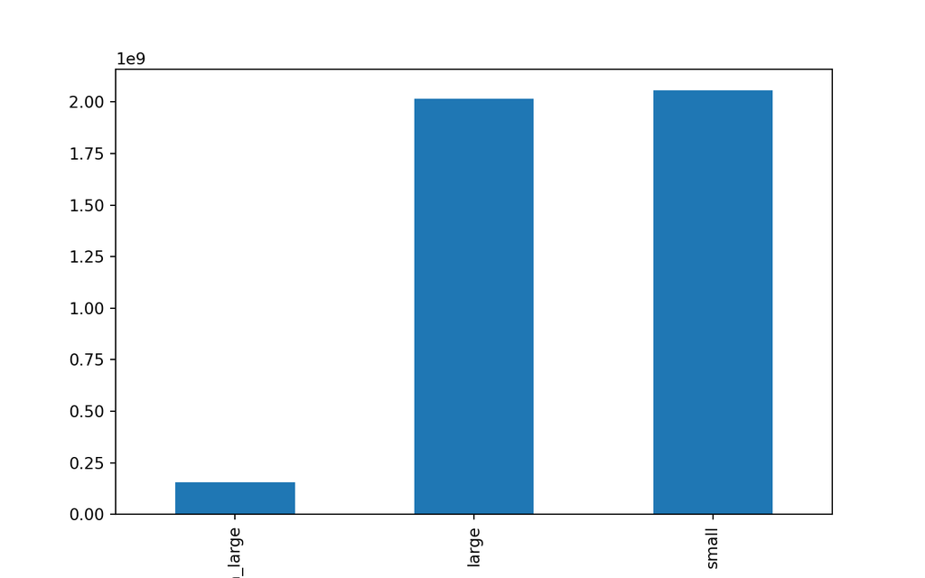

```python
# Create a bar plot of the number of avocados sold by size
nb_sold_by_size.plot(kind="bar")

# Show the plot
plt.show()
```

Bedazzling bar plot! It looks like small avocados were the most-purchased size, but large avocados were a close second.

### 4.1.2 Changes in sales over time

Line plots are designed to visualize the relationship between two numeric variables, where each data values is connected to the next one. They are especially useful for visualizing the change in a number over time since each time point is naturally connected to the next time point. In this exercise, you’ll visualize the change in avocado sales over three years.

`pandas` has been imported as `pd`, and `avocados` is available.

Get the total number of avocados sold on each date. *The DataFrame has two rows for each date—one for organic, and one for conventional*. Save this as `nb_sold_by_date`.

```python
# Import matplotlib.pyplot with alias plt
import matplotlib.pyplot as plt

# Get the total number of avocados sold on each date
nb_sold_by_date = avocados.groupby("date")["nb_sold"].sum()
```

Create a line plot of the number of avocados sold.

Show the plot.

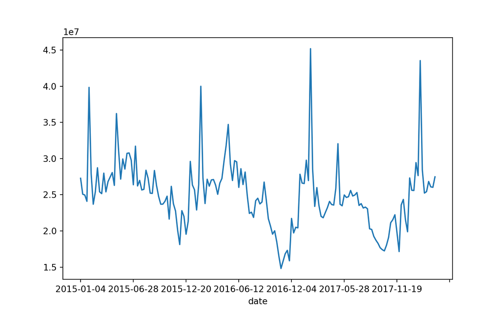

```python
# Create a line plot of the number of avocados sold by date
nb_sold_by_date.plot(kind="line")

# Show the plot
plt.show()
```

Lovely line plot! Line plots are great for visualizing something over time. Here, it looks like the number of avocados spikes around the same time each year.

### 4.1.3 Avocado supply and demand

Scatter plots are ideal for visualizing relationships between numerical variables. In this exercise, you’ll compare the number of avocados sold to average price and see if they’re at all related. If they’re related, you may be able to use one number to predict the other.

`matplotlib.pyplot` has been imported as `plt`, `pandas` has been imported as `pd`, and `avocados` is available.

Create a scatter plot with `nb_sold` on the x-axis and `avg_price` on the y-axis. Title it `“Number of avocados sold vs. average price”`.

Show the plot.

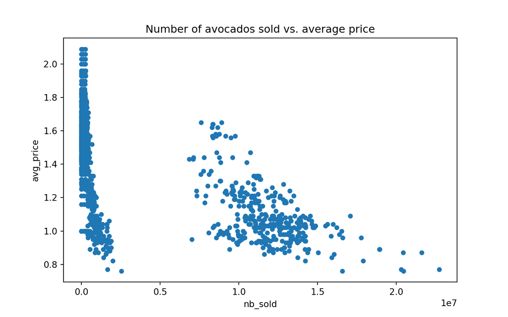

```python
# Scatter plot of avg_price vs. nb_sold with title
avocados.plot(x="nb_sold", y="avg_price", kind="scatter", title="Number of avocados sold vs. average price")

# Show the plot
plt.show()
```

Super scatter plot! It looks like when more avocados are sold, prices go down. However, this doesn’t mean that fewer sales *causes* higher prices - we can only tell that they’re correlated with each other.

### 4.1.4 Price of conventional vs. organic avocados

Creating multiple plots for different subsets of data allows you to compare groups. In this exercise, you’ll create multiple histograms to compare the prices of conventional and organic avocados.

`matplotlib.pyplot` has been imported as `plt` and `pandas` has been imported as `pd`.

Subset `avocados` for the conventional type, and the average price column. Create a histogram.

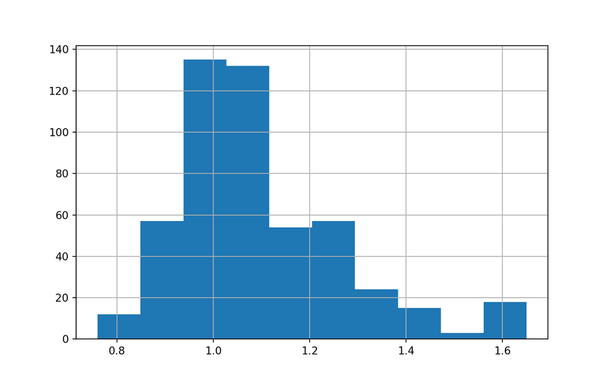

```python
# Histogram of conventional avg_price
avocados[avocados["type"] == "conventional"]["avg_price"].hist()
```

Create a histogram of `avg_price` for organic type avocados.

Add a legend to your plot, with the names “conventional” and “organic”.

Show your plot.

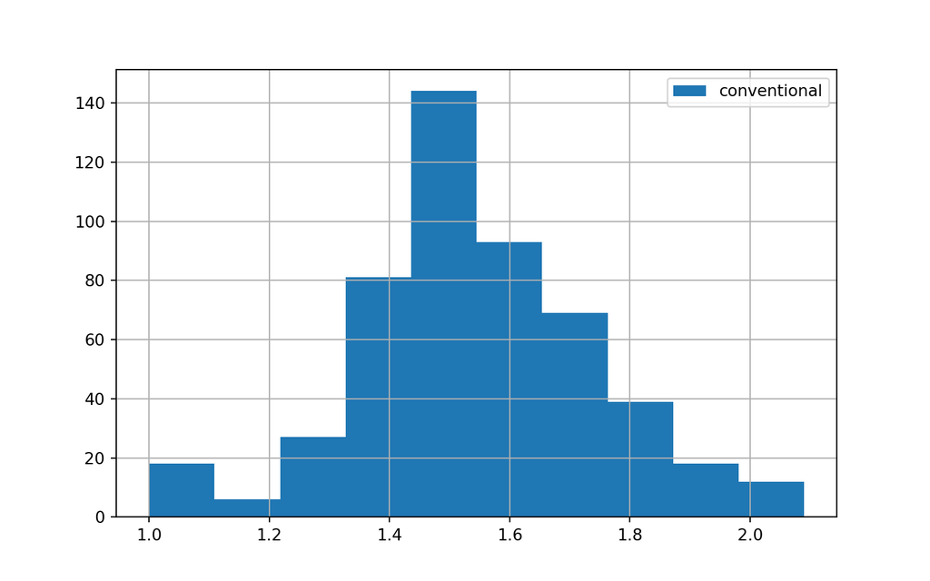

```python
# Histogram of organic avg_price
avocados[avocados["type"] == "organic"]["avg_price"].hist()

# Add a legend
plt.legend(["conventional", "organic"])

# Show the plot
plt.show()
```

Modify your code to adjust the transparency of both histograms to `0.5` to see how much overlap there is between the two distributions.

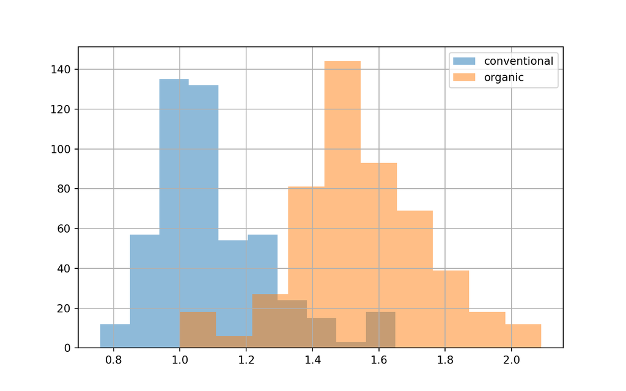

```python
# Modify histogram transparency to 0.5
avocados[avocados["type"] == "conventional"]["avg_price"].hist(alpha=0.5)

# Modify histogram transparency to 0.5
avocados[avocados["type"] == "organic"]["avg_price"].hist(alpha=0.5)

# Add a legend
plt.legend(["conventional", "organic"])

# Show the plot
plt.show()
```

Modify your code to use 20 bins in both histograms.

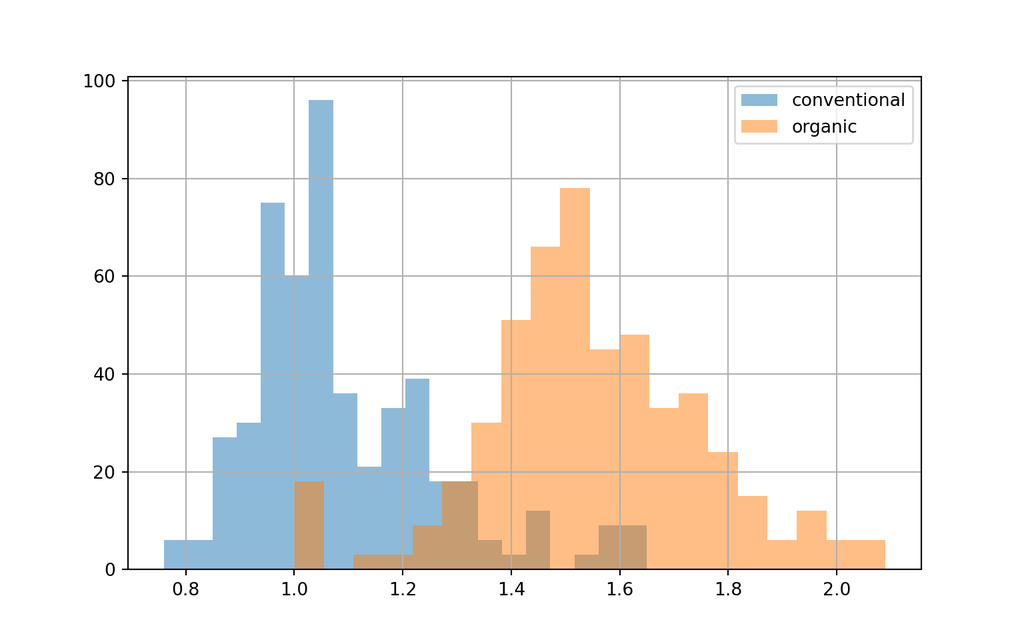

```python
# Modify bins to 20
avocados[avocados["type"] == "conventional"]["avg_price"].hist(bins=20, alpha=0.5)

# Modify bins to 20
avocados[avocados["type"] == "organic"]["avg_price"].hist(bins= 20, alpha=0.5)

# Add a legend
plt.legend(["conventional", "organic"])

# Show the plot
plt.show()
```

Great layering! We can see that on average, organic avocados are more expensive than conventional ones, but their price distributions have some overlap.

## 4.2 Missing values

### 4.2.1 Finding missing values

Missing values are everywhere, and you don’t want them interfering with your work. Some functions ignore missing data by default, but that’s not always the behavior you might want. Some functions can’t handle missing values at all, so these values need to be taken care of before you can use them. If you don’t know where your missing values are, or if they exist, you could make mistakes in your analysis. In this exercise, you’ll determine if there are missing values in the dataset, and if so, how many.

`pandas` has been imported as `pd` and `avocados_2016`, a subset of `avocados` that contains only sales from 2016, is available.

```python
# edited by cliex159
avocados_2016 = pd.read_csv('avocados_2016.csv')
cols_with_missing = ['small_sold', 'large_sold', 'xl_sold']
```

Print a DataFrame that shows whether each value in `avocados_2016` is missing or not.

```python
# Import matplotlib.pyplot with alias plt
import matplotlib.pyplot as plt

# Check individual values for missing values
print(avocados_2016.isna())
```

```
##      date  avg_price  ...  large_bags_sold  xl_bags_sold
## 0   False      False  ...            False         False
## 1   False      False  ...            False         False
## 2   False      False  ...            False         False
## 3   False      False  ...            False         False
## 4   False      False  ...            False         False
## 5   False      False  ...            False         False
## 6   False      False  ...            False         False
## 7   False      False  ...            False         False
## 8   False      False  ...            False         False
## 9   False      False  ...            False         False
## 10  False      False  ...            False         False
## 11  False      False  ...            False         False
## 12  False      False  ...            False         False
## 13  False      False  ...            False         False
```

[output cut: 40 more lines]

Print a summary that shows whether *any* value in each column is missing or not.

```python
# Check each column for missing values
print(avocados_2016.isna().any())
```

```
## date               False
## avg_price          False
## total_sold         False
## small_sold          True
## large_sold          True
## xl_sold             True
## total_bags_sold    False
## small_bags_sold    False
## large_bags_sold    False
## xl_bags_sold       False
## dtype: bool
```

Create a bar plot of the total number of missing values in each column.

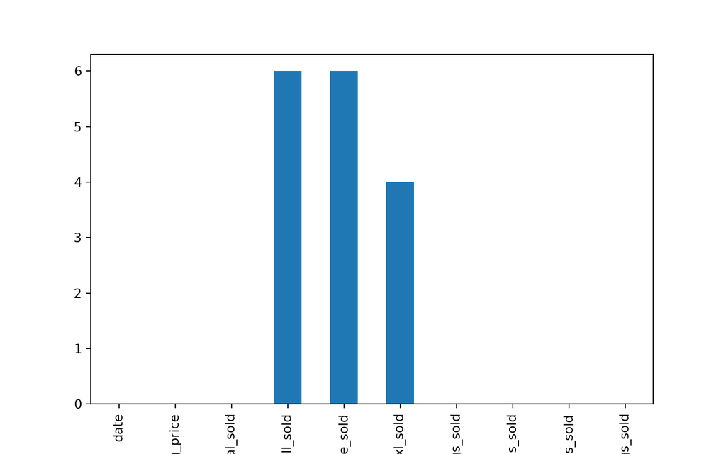

```python
# Bar plot of missing values by variable
avocados_2016.isna().sum().plot(kind="bar")

# Show plot
plt.show()
```

Marvelous missing value detection! It looks like there are missing values in the `small_sold`, `large_sold`, and `xl_sold` columns.

### 4.2.2 Removing missing values

Now that you know there are some missing values in your DataFrame, you have a few options to deal with them. One way is to remove them from the dataset completely. In this exercise, you’ll remove missing values by removing all rows that contain missing values.

`pandas` has been imported as `pd` and `avocados_2016` is available.

Remove the rows of `avocados_2016` that contain missing values and store the remaining rows in `avocados_complete`.

```python
# Remove rows with missing values
avocados_complete = avocados_2016.dropna()
```

Verify that all missing values have been removed from `avocados_complete`. Calculate each column that has NAs and print.

```python
# Check if any columns contain missing values
print(avocados_complete.isna().any())
```

```
## date               False
## avg_price          False
## total_sold         False
## small_sold         False
## large_sold         False
## xl_sold            False
## total_bags_sold    False
## small_bags_sold    False
## large_bags_sold    False
## xl_bags_sold       False
## dtype: bool
```

Delightful dropping! Removing observations with missing values is a quick and dirty way to deal with missing data, but this can introduce bias to your data if the values are not missing at random.

### 4.2.3 Replacing missing values

Another way of handling missing values is to replace them all with the same value. For numerical variables, one option is to replace values with 0— you’ll do this here. However, when you replace missing values, you make assumptions about what a missing value means. In this case, you will assume that a missing number sold means that no sales for that avocado type were made that week.

In this exercise, you’ll see how replacing missing values can affect the distribution of a variable using histograms. You can plot histograms for multiple variables at a time as follows:

```
dogs[["height_cm", "weight_kg"]].hist()
```

`pandas` has been imported as `pd` and `matplotlib.pyplot` has been imported as `plt`. The `avocados_2016` dataset is available.

A list has been created, `cols_with_missing`, containing the names of columns with missing values: `“small_sold”`, `“large_sold”`, and `“xl_sold”`.

```python
# List the columns with missing values
cols_with_missing = ["small_sold", "large_sold", "xl_sold"]
```

Create a histogram of those columns.

Show the plot.

```python
# Create histograms showing the distributions cols_with_missing
avocados_2016[cols_with_missing].hist()

# Show the plot
```

```
## array([[<AxesSubplot:title={'center':'small_sold'}>,
##         <AxesSubplot:title={'center':'large_sold'}>],
##        [<AxesSubplot:title={'center':'xl_sold'}>, <AxesSubplot:>]],
##       dtype=object)
```

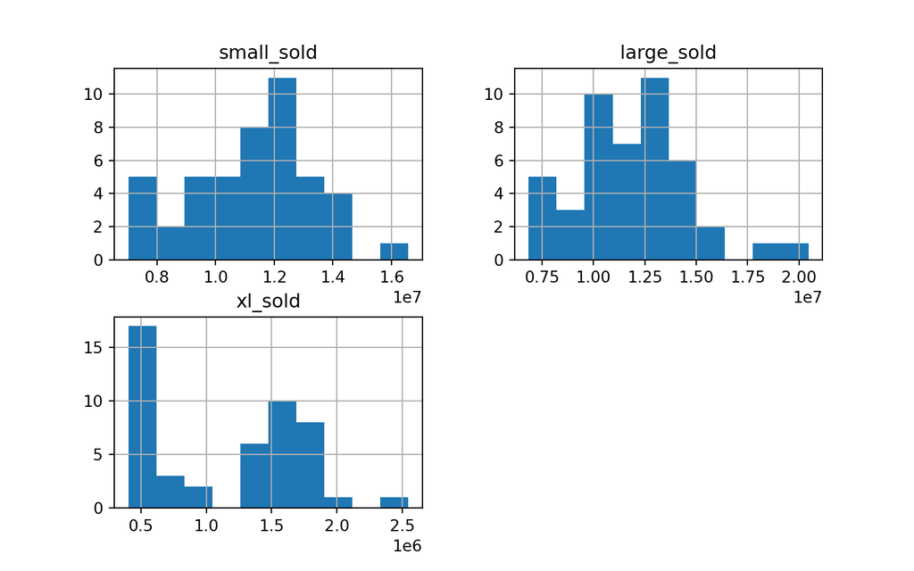

```python
plt.show()
```

Replace the missing values of `avocados_2016` with `0`s and store the result as `avocados_filled`.

```python
# From previous step
cols_with_missing = ["small_sold", "large_sold", "xl_sold"]
avocados_2016[cols_with_missing].hist()
```

```
## array([[<AxesSubplot:title={'center':'small_sold'}>,
##         <AxesSubplot:title={'center':'large_sold'}>],
##        [<AxesSubplot:title={'center':'xl_sold'}>, <AxesSubplot:>]],
##       dtype=object)
```

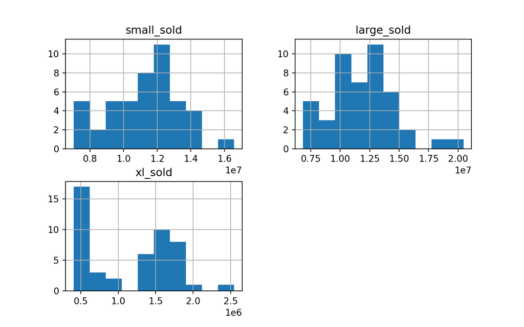

```python
plt.show()
```

Create a histogram of the `cols_with_missing` columns of `avocados_filled`.

```python
# Fill in missing values with 0
avocados_filled = avocados_2016.fillna(0)

# Create histograms of the filled columns
avocados_filled[cols_with_missing].hist()

# Show the plot
```

```
## array([[<AxesSubplot:title={'center':'small_sold'}>,
##         <AxesSubplot:title={'center':'large_sold'}>],
##        [<AxesSubplot:title={'center':'xl_sold'}>, <AxesSubplot:>]],
##       dtype=object)
```

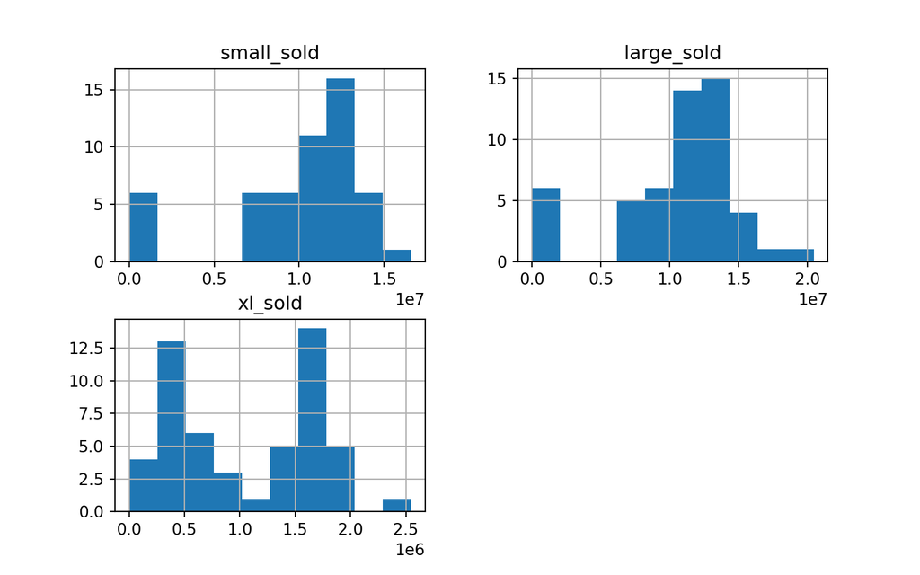

```python
plt.show()
```

Fabulous filling! Notice how the distribution has changed shape after replacing missing values with zeros.

## 4.3 Creating DataFrames

### 4.3.1 List of dictionaries

You recently got some new avocado data from 2019 that you’d like to put in a DataFrame using the list of dictionaries method. Remember that with this method, you go through the data row by row.

| date | small_sold | large_sold |
| --- | --- | --- |
| “2019-11-03” | 10376832 | 7835071 |
| “2019-11-10” | 10717154 | 8561348 |

`pandas` as `pd` is imported.

Create a list of dictionaries with the new data called `avocados_list`.

```python
# Create a list of dictionaries with new data
avocados_list = [
    {"date": "2019-11-03", "small_sold": 10376832, "large_sold": 7835071},
    {"date": "2019-11-10", "small_sold": 10717154, "large_sold": 8561348},
]
```

Convert the list into a DataFrame called `avocados_2019`.

```python
# Convert list into DataFrame
avocados_2019 = pd.DataFrame(avocados_list)
```

Print your new DataFrame.

```python
# Print the new DataFrame
print(avocados_2019)
```

```
##          date  small_sold  large_sold
## 0  2019-11-03    10376832     7835071
## 1  2019-11-10    10717154     8561348
```

Lovely work with the list-of-dictionaries! The list-of-dictionaries method creates DataFrames row-by-row.

### 4.3.2 Dictionary of lists

Some more data just came in! This time, you’ll use the dictionary of lists method, parsing the data column by column.

| date | small_sold | large_sold |
| --- | --- | --- |
| “2019-11-17” | 10859987 | 7674135 |
| “2019-12-01” | 9291631 | 6238096 |

`pandas` as `pd` is imported.

Create a dictionary of lists with the new data called `avocados_dict`.

```python
# Create a dictionary of lists with new data
avocados_dict = {
  "date": ["2019-11-17", "2019-12-01"],
  "small_sold": [10859987, 9291631],
  "large_sold": [7674135, 6238096]
}
```

Convert the dictionary to a DataFrame called `avocados_2019`.

```python
# Convert dictionary into DataFrame
avocados_2019 = pd.DataFrame(avocados_dict)
```

Print your new DataFrame.

```python
# Print the new DataFrame
print(avocados_2019)
```

```
##          date  small_sold  large_sold
## 0  2019-11-17    10859987     7674135
## 1  2019-12-01     9291631     6238096
```

## 4.4 Reading and writing CSVs

### 4.4.1 CSV to DataFrame

You work for an airline, and your manager has asked you to do a competitive analysis and see how often passengers flying on other airlines are involuntarily bumped from their flights. You got a CSV file (`airline_bumping.csv`) from the Department of Transportation containing data on passengers that were involuntarily denied boarding in 2016 and 2017, but it doesn’t have the exact numbers you want. In order to figure this out, you’ll need to get the CSV into a pandas DataFrame and do some manipulation!

`pandas` is imported for you as `pd`. `“airline_bumping.csv”` is in your working directory.

Read the CSV file `“airline_bumping.csv”` and store it as a DataFrame called `airline_bumping`.

```python
# Read CSV as DataFrame called airline_bumping
airline_bumping = pd.read_csv('airline_bumping.csv')
```

Print the first few rows of `airline_bumping`.

```python
# Take a look at the DataFrame
print(airline_bumping.head())
```

```
##              airline  year  nb_bumped  total_passengers
## 0    DELTA AIR LINES  2017        679          99796155
## 1     VIRGIN AMERICA  2017        165           6090029
## 2    JETBLUE AIRWAYS  2017       1475          27255038
## 3    UNITED AIRLINES  2017       2067          70030765
## 4  HAWAIIAN AIRLINES  2017         92           8422734
```

For each airline group, select the `nb_bumped`, and `total_passengers` columns, and calculate the sum (for both years). Store this as `airline_totals`.

```python
# For each airline, select nb_bumped and total_passengers and sum
airline_totals = airline_bumping.groupby("airline")[["nb_bumped", "total_passengers"]].sum()
```

Create a new column of `airline_totals` called `bumps_per_10k`, which is the number of passengers bumped per 10,000 passengers in 2016 and 2017.

```python
# Create new col, bumps_per_10k: no. of bumps per 10k passengers for each airline
airline_totals["bumps_per_10k"] = airline_totals["nb_bumped"] / airline_totals["total_passengers"] * 10000

# Print airline_totals
print(airline_totals)
```

```
##                      nb_bumped  total_passengers  bumps_per_10k
## airline
## ALASKA AIRLINES           1392          36543121       0.380920
## AMERICAN AIRLINES        11115         197365225       0.563169
## DELTA AIR LINES           1591         197033215       0.080748
## EXPRESSJET AIRLINES       3326          27858678       1.193883
## FRONTIER AIRLINES         1228          22954995       0.534960
## HAWAIIAN AIRLINES          122          16577572       0.073593
## JETBLUE AIRWAYS           3615          53245866       0.678926
## SKYWEST AIRLINES          3094          47091737       0.657015
## SOUTHWEST AIRLINES       18585         228142036       0.814624
## SPIRIT AIRLINES           2920          32304571       0.903897
## UNITED AIRLINES           4941         134468897       0.367446
## VIRGIN AMERICA             242          12017967       0.201365
```

Print `airline_totals` to see the results of your manipulations.

```python
# Print airline_totals
print(airline_totals)
```

```
##                      nb_bumped  total_passengers  bumps_per_10k
## airline
## ALASKA AIRLINES           1392          36543121       0.380920
## AMERICAN AIRLINES        11115         197365225       0.563169
## DELTA AIR LINES           1591         197033215       0.080748
## EXPRESSJET AIRLINES       3326          27858678       1.193883
## FRONTIER AIRLINES         1228          22954995       0.534960
## HAWAIIAN AIRLINES          122          16577572       0.073593
## JETBLUE AIRWAYS           3615          53245866       0.678926
## SKYWEST AIRLINES          3094          47091737       0.657015
## SOUTHWEST AIRLINES       18585         228142036       0.814624
## SPIRIT AIRLINES           2920          32304571       0.903897
## UNITED AIRLINES           4941         134468897       0.367446
## VIRGIN AMERICA             242          12017967       0.201365
```

Masterful manipulation! Now you’ll need to export this so you can share it with others.

### 4.4.2 DataFrame to CSV

You’re almost there! To make things easier to read, you’ll need to sort the data and export it to CSV so that your colleagues can read it.

`pandas` as `pd` has been imported for you.

Sort `airline_totals` by the values of `bumps_per_10k` from highest to lowest, storing as `airline_totals_sorted`.

```python
# Create airline_totals_sorted
airline_totals_sorted = airline_totals.sort_values("bumps_per_10k", ascending=False)
```

Print your sorted DataFrame.

```python
# Print airline_totals_sorted
print(airline_totals_sorted)
```

```
##                      nb_bumped  total_passengers  bumps_per_10k
## airline
## EXPRESSJET AIRLINES       3326          27858678       1.193883
## SPIRIT AIRLINES           2920          32304571       0.903897
## SOUTHWEST AIRLINES       18585         228142036       0.814624
## JETBLUE AIRWAYS           3615          53245866       0.678926
## SKYWEST AIRLINES          3094          47091737       0.657015
## AMERICAN AIRLINES        11115         197365225       0.563169
## FRONTIER AIRLINES         1228          22954995       0.534960
## ALASKA AIRLINES           1392          36543121       0.380920
## UNITED AIRLINES           4941         134468897       0.367446
## VIRGIN AMERICA             242          12017967       0.201365
## DELTA AIR LINES           1591         197033215       0.080748
## HAWAIIAN AIRLINES          122          16577572       0.073593
```

Save the sorted DataFrame as a CSV called `“airline_totals_sorted.csv”`.

```python
# Save as airline_totals_sorted.csv
airline_totals_sorted.to_csv("airline_totals_sorted.csv")
```

Excellent exporting! Now you can share these insights about your competitors with your team.